# UNIVERSIDAD TECNOLÓGICA DE XICOTEPEC DE JUAREZ

Ingeniería en Desarrollo y Gestión de Software

## 🧠 Práctica 09

### Algoritmos de Análisis No Supervisado

#### Segmentación de Clientes de Centros Comerciales — K-Means Clustering

| **Asignatura** | Extracción de Conocimiento en Bases de Datos |
| --- | --- |
| **Unidad** | Unidad 4 — Aprendizaje No Supervisado |
| **Estudiante** | Luis Daniel Suárez Escamilla |
| **Matrícula** | 230040 |
| **Grupo** | 9A — IDGS |
| **Docente** | M.T.I. Marco A. Ramírez Hernández |
| **Periodo** | Mayo – Agosto 2026 |
| **Valor** | 50 Firmas |
| **Fecha** | Agosto 2026 |

## 📋 Tabla de Contenidos

| # | Sección | Descripción |
| --- | --- | --- |
| 1 | Introducción | Aprendizaje No Supervisado y K-Means |
| 2 | Librerías e Importaciones | Importación y descripción del entorno |
| 3 | Carga del Dataset | Lectura y primeras observaciones |
| 4 | Estructura del Dataset | Variables, tipos y descripción |
| 5 | Calidad de Datos | Nulos, duplicados, inconsistencias |
| 6 | Estadísticas Descriptivas | Análisis estadístico numérico |
| 7 | Análisis Univariado | Visualizaciones por variable |
| 8 | Valores Atípicos (Outliers) | Boxplots y detección |
| 9 | Análisis Bivariado y Multivariado | Relaciones entre variables |
| 10 | Codificación de Variables | LabelEncoder para Gender |
| 11 | Normalización | Escalamiento de datos |
| 12 | Matrices de Características | Combinaciones de variables |
| 13 | Método del Codo y Silueta | Selección del número óptimo de k |
| 14 | Modelado K-Means | Entrenamiento y visualización |
| 15 | Conclusiones | Perfiles, comparaciones y limitaciones |

## 🔬 1. Introducción

### ¿Qué es el Aprendizaje No Supervisado?

El **aprendizaje no supervisado** (Unsupervised Learning) es una rama del machine learning en la que el algoritmo trabaja con datos que **no tienen etiquetas o categorías predefinidas**. A diferencia del aprendizaje supervisado —donde le decimos al modelo cuál es la respuesta correcta— aquí el algoritmo debe encontrar por sí mismo la estructura, los patrones y las relaciones ocultas en los datos.

Es como darle a alguien un montón de fotografías sin nombre y pedirle que las agrupe como crea conveniente. Esa persona podría agruparlas por colores, por paisajes o por personas, sin que nadie le dijera cómo hacerlo.

### ¿Qué problema resuelve el agrupamiento (Clustering)?

El **agrupamiento** o clustering resuelve el problema de **segmentación**: encontrar subgrupos naturales dentro de un conjunto de datos. Esto es útil cuando queremos:

- Descubrir segmentos de clientes con comportamientos similares
- Identificar patrones en datos médicos o biológicos
- Detectar anomalías o grupos inusuales
- Reducir la complejidad de grandes conjuntos de datos

La idea clave es que los elementos **dentro de un mismo grupo** deben ser muy similares entre sí, y los elementos de **grupos diferentes** deben ser muy distintos entre ellos.

### ¿Por qué aplicar K-Means en la segmentación de clientes?

**K-Means** es uno de los algoritmos de clustering más populares y eficientes. Su funcionamiento básico es:

1. Se elige el número `k` de grupos deseados
2. Se colocan `k` centros de forma aleatoria (centroides)
3. Cada punto se asigna al centroide más cercano
4. Los centroides se recalculan como el promedio de los puntos asignados
5. Se repiten los pasos 3-4 hasta que los centroides no se muevan significativamente

En el contexto de un **centro comercial**, K-Means nos permite segmentar a los clientes según su ingreso anual, su puntaje de gasto y su edad, identificando perfiles como:

- Clientes jóvenes con alto gasto y bajo ingreso
- Clientes maduros con alto ingreso pero gasto conservador
- El segmento "ideal" con alto ingreso y alto gasto

Esta información es extremadamente valiosa para las estrategias de marketing, campañas personalizadas y toma de decisiones comerciales.

### 💬 Conclusiones Personales — Introducción

Lo que más me llamó la atención de esta sección es que el aprendizaje no supervisado básicamente le da libertad al algoritmo para que él mismo decida cómo organizar los datos. En el mundo real esto tiene muchísimo sentido para empresas que quieren entender a sus clientes sin saber de antemano cuántos tipos de clientes tienen. No es que el modelo "aprenda" como un humano aprende, sino que encuentra similitudes matemáticas entre los datos. En el caso del centro comercial, me parece super útil porque con solo tres o cuatro variables puedes construir perfiles de clientes que de otra manera tomarían meses de encuestas y análisis manual.

## 📦 2. Librerías e Importaciones

### Descripción de las librerías utilizadas

| Librería | Versión Mínima | Función Principal |
| --- | --- | --- |
| **Pandas** | ≥ 2.0 | Manipulación y análisis de datos en estructuras tipo tabla (DataFrames) |
| **NumPy** | ≥ 1.24 | Operaciones numéricas eficientes y manejo de arreglos multidimensionales |
| **Matplotlib** | ≥ 3.7 | Librería base para crear gráficas y visualizaciones |
| **Seaborn** | ≥ 0.12 | Visualizaciones estadísticas avanzadas sobre Matplotlib |
| **Scikit-learn** | ≥ 1.2 | Algoritmos de machine learning: K-Means, métricas, preprocesamiento |
| **Warnings** | stdlib | Suprimir advertencias no críticas del entorno |

### ¿Para qué sirve cada una?

- **Pandas**: Nos permite cargar el CSV, explorar el DataFrame, filtrar filas, renombrar columnas y hacer operaciones de agrupación. Es el corazón del manejo de datos.
- **NumPy**: Proporciona la base matemática. Se usa internamente por casi todas las librerías de ML y nos permite hacer operaciones vectorizadas muy rápidas.
- **Matplotlib**: Crea las gráficas de forma. Sin ella, Seaborn tampoco funcionaría. Usamos `plt.figure`, `plt.show`, `plt.subplots` constantemente.
- **Seaborn**: Hace gráficas más bonitas con menos código. Es perfecta para histogramas, boxplots, heatmaps y gráficas de dispersión con colores automáticos.
- **Scikit-learn**: Aquí viven el algoritmo `KMeans`, el `silhouette_score`, `LabelEncoder` y `StandardScaler`. Es la herramienta central del modelado.

```python
# ============================================================
# Instalación de dependencias (ejecutar solo si es necesario)
# ============================================================
%pip install matplotlib pandas numpy seaborn scikit-learn --quiet
```

```python
# ============================================================
# SECCIÓN 2: Importación de Librerías
# ============================================================

# Manipulación y análisis de datos
import numpy as np
import pandas as pd

# Visualización
import matplotlib.pyplot as plt
import matplotlib.patches as mpatches
import seaborn as sns
%matplotlib inline

# Machine Learning — Scikit-learn
from sklearn.cluster import KMeans
from sklearn.metrics import silhouette_score
from sklearn.preprocessing import LabelEncoder, StandardScaler

# Utilidades del sistema
import warnings
warnings.filterwarnings('ignore')

# Configuración global de estilo
sns.set_style('darkgrid')
plt.rcParams['figure.figsize'] = (10, 6)
plt.rcParams['font.size'] = 11

print("✅ Todas las librerías importadas correctamente")
```

```
✅ Todas las librerías importadas correctamente
```

```python
# ============================================================
# Verificación de versiones del entorno
# ============================================================
import sys
import sklearn

print(f"🐍 Python     : {sys.version.split()[0]}")
print(f"📦 NumPy      : {np.__version__}")
print(f"📋 Pandas     : {pd.__version__}")
print(f"📊 Matplotlib : {plt.matplotlib.__version__}")
print(f"📈 Seaborn    : {sns.__version__}")
print(f"🤖 Scikit-learn: {sklearn.__version__}")
```

```
🐍 Python     : 3.13.9
📦 NumPy      : 2.3.5
📋 Pandas     : 2.3.3
📊 Matplotlib : 3.10.6
📈 Seaborn    : 0.13.2
🤖 Scikit-learn: 1.7.2
```

### 💬 Conclusiones Personales — Librerías

Antes de esta práctica no me había detenido a pensar en por qué importamos tantas librerías distintas si todas hacen cosas con datos. Ahora que lo entiendo mejor, cada una tiene su especialidad: Pandas es para organizar y limpiar, NumPy para los cálculos matemáticos de fondo, Matplotlib y Seaborn para ver los resultados visualmente, y Scikit-learn para el aprendizaje automático. Es como un equipo donde cada integrante hace algo diferente. Lo de verificar versiones también es importante porque muchas veces el código falla por incompatibilidades y si no sabes la versión no sabes dónde buscar el error.

## 📂 3. Carga del Dataset

El dataset **Mall_Customers.csv** contiene información sobre 200 clientes de un centro comercial. Fue creado con fines educativos para practicar técnicas de segmentación mediante aprendizaje no supervisado. Su origen es Kaggle: [Mall Customer Segmentation Data](https://www.kaggle.com/datasets/vjchoudhary7/customer-segmentation-tutorial-in-python).

A continuación cargamos el archivo y realizamos una primera inspección visual para confirmar que se cargó correctamente.

```python
# ============================================================
# SECCIÓN 3: Carga del Dataset
# ============================================================

# Carga del archivo CSV
df = pd.read_csv('Mall_Customers.csv')

print(f"✅ Dataset cargado exitosamente")
print(f"   Forma del dataset: {df.shape[0]} filas × {df.shape[1]} columnas")
print()

# Primeras observaciones
print("📋 Primeras 5 filas del dataset (head):")
display(df.head())
```

```
✅ Dataset cargado exitosamente
   Forma del dataset: 200 filas × 5 columnas

📋 Primeras 5 filas del dataset (head):
```

|  | CustomerID | Gender | Age | Annual Income (k$) | Spending Score (1-100) |
| --- | --- | --- | --- | --- | --- |
| 0 | 1 | Male | 19 | 15 | 39 |
| 1 | 2 | Male | 21 | 15 | 81 |
| 2 | 3 | Female | 20 | 16 | 6 |
| 3 | 4 | Female | 23 | 16 | 77 |
| 4 | 5 | Female | 31 | 17 | 40 |

```python
# Últimas observaciones del dataset
print("📋 Últimas 5 filas del dataset (tail):")
display(df.tail())
```

```
📋 Últimas 5 filas del dataset (tail):
```

|  | CustomerID | Gender | Age | Annual Income (k$) | Spending Score (1-100) |
| --- | --- | --- | --- | --- | --- |
| 195 | 196 | Female | 35 | 120 | 79 |
| 196 | 197 | Female | 45 | 126 | 28 |
| 197 | 198 | Male | 32 | 126 | 74 |
| 198 | 199 | Male | 32 | 137 | 18 |
| 199 | 200 | Male | 30 | 137 | 83 |

### 💬 Conclusiones Personales — Carga del Dataset

Con solo ver las primeras y últimas filas ya puedo intuir cómo están distribuidos los datos. Por ejemplo, los CustomerIDs van del 1 al 200, lo que confirma que hay exactamente 200 registros. También se puede ver que hay clientes tanto masculinos como femeninos, y que los rangos de ingreso y puntuación de gasto varían bastante. Es un dataset pequeño pero muy limpio visualmente, lo que facilita mucho trabajar con él. Ver el tail también ayuda a confirmar que no hay datos raros al final del archivo como suele pasar cuando los CSVs se exportan mal.

## 🏗️ 4. Estructura del Dataset

### Descripción de las variables

| Variable | Tipo | Descripción |
| --- | --- | --- |
| **CustomerID** | Entero (int64) | Identificador único de cada cliente. No aporta información analítica. |
| **Gender** | Texto (object) | Género del cliente: `Male` (Masculino) o `Female` (Femenino). |
| **Age** | Entero (int64) | Edad del cliente en años. |
| **Annual Income (k$)** | Entero (int64) | Ingreso anual del cliente expresado en miles de dólares (USD). |
| **Spending Score (1-100)** | Entero (int64) | Puntaje de gasto asignado por el centro comercial (1 = menor gasto, 100 = mayor gasto). |

```python
# ============================================================
# SECCIÓN 4: Estructura del Dataset
# ============================================================

print("📐 Forma del dataset:")
print(f"   {df.shape[0]} registros (filas) × {df.shape[1]} columnas")
print()

print("📋 Información general del dataset (info):")
df.info()
```

```
📐 Forma del dataset:
   200 registros (filas) × 5 columnas

📋 Información general del dataset (info):
<class 'pandas.core.frame.DataFrame'>
RangeIndex: 200 entries, 0 to 199
Data columns (total 5 columns):
 #   Column                  Non-Null Count  Dtype
---  ------                  --------------  -----
 0   CustomerID              200 non-null    int64
 1   Gender                  200 non-null    object
 2   Age                     200 non-null    int64
 3   Annual Income (k$)      200 non-null    int64
 4   Spending Score (1-100)  200 non-null    int64
dtypes: int64(4), object(1)
memory usage: 7.9+ KB
```

```python
# Tipos de datos de cada columna
print("🔢 Tipos de datos por columna:")
print(df.dtypes)
print()

# Nombres de columnas
print("📌 Nombres de columnas:")
for i, col in enumerate(df.columns):
    print(f"   [{i}] {col}")
```

```
🔢 Tipos de datos por columna:
CustomerID                 int64
Gender                    object
Age                        int64
Annual Income (k$)         int64
Spending Score (1-100)     int64
dtype: object

📌 Nombres de columnas:
   [0] CustomerID
   [1] Gender
   [2] Age
   [3] Annual Income (k$)
   [4] Spending Score (1-100)
```

### 💬 Conclusiones Personales — Estructura del Dataset

Lo que noto aquí es que el dataset es bastante sencillo: solo 200 filas y 5 columnas. La mayoría de las variables son numéricas enteras, excepto Gender que es texto. Eso significa que antes de aplicar K-Means tendré que convertir Gender a número porque el algoritmo solo trabaja con valores numéricos. CustomerID no lo vamos a usar para el clustering porque es solo un identificador, no una característica real del cliente. La columna de Spending Score me llama la atención porque es una puntuación subjetiva asignada por el mall, lo que le da cierto sabor de evaluación interna que puede ser muy informativa.

## 🔍 5. Revisión de Calidad de los Datos

Antes de comenzar cualquier análisis o modelado, es fundamental verificar que los datos estén en buen estado. Una base de datos con errores produce modelos incorrectos, independientemente de qué tan bueno sea el algoritmo que usemos: *"garbage in, garbage out"* (basura entra, basura sale).

Revisaremos los siguientes aspectos:

- Valores nulos o faltantes (NaN)
- Registros duplicados
- Valores únicos por columna
- Rangos de valores incorrectos
- Inconsistencias en datos categóricos

```python
# ============================================================
# SECCIÓN 5: Calidad de Datos
# ============================================================

# --- 5.1 Valores Nulos ---
print("🔴 5.1 Valores Nulos por Columna:")
nulos = df.isnull().sum()
pct_nulos = (nulos / len(df) * 100).round(2)
reporte_nulos = pd.DataFrame({'Nulos': nulos, '% del Total': pct_nulos})
print(reporte_nulos)
print(f"\n   → Total de valores nulos en el dataset: {nulos.sum()}")
```

```
🔴 5.1 Valores Nulos por Columna:
                        Nulos  % del Total
CustomerID                  0          0.0
Gender                      0          0.0
Age                         0          0.0
Annual Income (k$)          0          0.0
Spending Score (1-100)      0          0.0

   → Total de valores nulos en el dataset: 0
```

```python
# --- 5.2 Registros Duplicados ---
print("🔴 5.2 Registros Duplicados:")
duplicados = df.duplicated().sum()
print(f"   → Número de filas completamente duplicadas: {duplicados}")

if duplicados > 0:
    print("\n   ⚠️  Se detectaron duplicados. Mostrando registros:")
    display(df[df.duplicated()])
else:
    print("   ✅ No se encontraron registros duplicados.")
```

```
🔴 5.2 Registros Duplicados:
   → Número de filas completamente duplicadas: 0
   ✅ No se encontraron registros duplicados.
```

```python
# --- 5.3 Valores Únicos por Columna ---
print("📌 5.3 Valores Únicos por Columna:")
for col in df.columns:
    unicos = df[col].nunique()
    print(f"   {col}: {unicos} valores únicos")
    if df[col].dtype == 'object':
        print(f"         → Valores: {df[col].unique().tolist()}")
```

```
📌 5.3 Valores Únicos por Columna:
   CustomerID: 200 valores únicos
   Gender: 2 valores únicos
         → Valores: ['Male', 'Female']
   Age: 51 valores únicos
   Annual Income (k$): 64 valores únicos
   Spending Score (1-100): 84 valores únicos
```

```python
# --- 5.4 Rangos y Consistencia de Variables Numéricas ---
print("📊 5.4 Verificación de Rangos:")
print()

rangos_esperados = {
    'Age': (18, 100, 'años'),
    'Annual Income (k$)': (0, 500, 'miles USD'),
    'Spending Score (1-100)': (1, 100, 'puntos')
}

for col, (min_esp, max_esp, unidad) in rangos_esperados.items():
    min_real = df[col].min()
    max_real = df[col].max()
    fuera = df[(df[col] < min_esp) | (df[col] > max_esp)].shape[0]
    estado = '✅' if fuera == 0 else '⚠️'
    print(f"   {estado} {col}:")
    print(f"      Rango esperado: [{min_esp}, {max_esp}] {unidad}")
    print(f"      Rango real:     [{min_real}, {max_real}] {unidad}")
    print(f"      Valores fuera de rango: {fuera}")
    print()

# Consistencia de Gender
print("👥 5.5 Consistencia de Gender:")
print(df['Gender'].value_counts())
inesperados = df[~df['Gender'].isin(['Male', 'Female'])]
if len(inesperados) == 0:
    print("   ✅ Todos los valores de Gender son válidos.")
```

```
📊 5.4 Verificación de Rangos:

   ✅ Age:
      Rango esperado: [18, 100] años
      Rango real:     [18, 70] años
      Valores fuera de rango: 0

   ✅ Annual Income (k$):
      Rango esperado: [0, 500] miles USD
      Rango real:     [15, 137] miles USD
      Valores fuera de rango: 0

   ✅ Spending Score (1-100):
      Rango esperado: [1, 100] puntos
      Rango real:     [1, 99] puntos
      Valores fuera de rango: 0

👥 5.5 Consistencia de Gender:
Gender
Female    112
Male       88
Name: count, dtype: int64
   ✅ Todos los valores de Gender son válidos.
```

### Resumen de Calidad de Datos

| Verificación | Resultado |
| --- | --- |
| Valores nulos | ✅ Ninguno |
| Registros duplicados | ✅ Ninguno |
| Rangos de Age | ✅ Dentro del rango esperado |
| Rangos de Annual Income | ✅ Dentro del rango esperado |
| Rangos de Spending Score | ✅ Dentro del rango esperado |
| Consistencia de Gender | ✅ Solo valores 'Male' y 'Female' |

**Conclusión**: El dataset es un conjunto educativo muy limpio. No requiere ninguna limpieza adicional antes del análisis.

### 💬 Conclusiones Personales — Calidad de Datos

Encontrar que el dataset no tiene ningún nulo, duplicado o valor fuera de rango es una buena noticia, aunque también es esperable porque este dataset fue creado específicamente con fines educativos. En proyectos reales casi siempre hay algo que limpiar. De hecho, en la mayoría de proyectos de ciencia de datos, la limpieza de datos toma más del 60% del tiempo total. Aun así, hacer esta revisión siempre es importante porque si hubiera un error y no lo detectamos desde el inicio, los resultados del clustering serían completamente equivocados y nunca sabríamos por qué.

## 📊 6. Estadísticas Descriptivas

Las estadísticas descriptivas nos dan un resumen numérico de cómo se distribuye cada variable. Son el primer paso para entender el "comportamiento" de los datos antes de visualizarlos.

**Métricas clave a interpretar:**

- **Media (mean)**: Promedio aritmético. Sensible a valores extremos.
- **Desviación estándar (std)**: Qué tan dispersos están los datos respecto a la media. Mayor std = mayor variabilidad.
- **Mínimo/Máximo**: Valores extremos del conjunto.
- **Q1 (25%)**: El 25% de los datos está por debajo de este valor.
- **Mediana (50%)**: El valor central. Si difiere mucho de la media, hay sesgo.
- **Q3 (75%)**: El 75% de los datos está por debajo de este valor.

```python
# ============================================================
# SECCIÓN 6: Estadísticas Descriptivas
# ============================================================

print("📊 Estadísticas descriptivas de variables numéricas:")
desc = df.describe().T
desc['rango'] = desc['max'] - desc['min']
desc['cv (%)'] = (desc['std'] / desc['mean'] * 100).round(2)
display(desc.round(2))
```

```
📊 Estadísticas descriptivas de variables numéricas:
```

|  | count | mean | std | min | 25% | 50% | 75% | max | rango | cv (%) |
| --- | --- | --- | --- | --- | --- | --- | --- | --- | --- | --- |
| CustomerID | 200.0 | 100.50 | 57.88 | 1.0 | 50.75 | 100.5 | 150.25 | 200.0 | 199.0 | 57.59 |
| Age | 200.0 | 38.85 | 13.97 | 18.0 | 28.75 | 36.0 | 49.00 | 70.0 | 52.0 | 35.96 |
| Annual Income (k$) | 200.0 | 60.56 | 26.26 | 15.0 | 41.50 | 61.5 | 78.00 | 137.0 | 122.0 | 43.37 |
| Spending Score (1-100) | 200.0 | 50.20 | 25.82 | 1.0 | 34.75 | 50.0 | 73.00 | 99.0 | 98.0 | 51.44 |

```python
# Interpretación detallada por variable
print("📌 Interpretación por variable:")
print()

print("👤 Edad (Age):")
print(f"   Media: {df['Age'].mean():.1f} años | Mediana: {df['Age'].median():.1f} años")
print(f"   Rango: {df['Age'].min()} – {df['Age'].max()} años")
print(f"   La mayoría de clientes tiene entre {df['Age'].quantile(0.25):.0f} y {df['Age'].quantile(0.75):.0f} años")
print()

print("💰 Ingreso Anual (Annual Income):")
print(f"   Media: ${df['Annual Income (k$)'].mean():.1f}k | Mediana: ${df['Annual Income (k$)'].median():.1f}k")
print(f"   Rango: ${df['Annual Income (k$)'].min()}k – ${df['Annual Income (k$)'].max()}k")
print()

print("🛒 Puntuación de Gasto (Spending Score):")
print(f"   Media: {df['Spending Score (1-100)'].mean():.1f} | Mediana: {df['Spending Score (1-100)'].median():.1f}")
print(f"   Rango: {df['Spending Score (1-100)'].min()} – {df['Spending Score (1-100)'].max()}")
```

```
📌 Interpretación por variable:

👤 Edad (Age):
   Media: 38.9 años | Mediana: 36.0 años
   Rango: 18 – 70 años
   La mayoría de clientes tiene entre 29 y 49 años

💰 Ingreso Anual (Annual Income):
   Media: $60.6k | Mediana: $61.5k
   Rango: $15k – $137k

🛒 Puntuación de Gasto (Spending Score):
   Media: 50.2 | Mediana: 50.0
   Rango: 1 – 99
```

### 💬 Conclusiones Personales — Estadísticas Descriptivas

Las estadísticas descriptivas me muestran que la edad promedio de los clientes ronda los 38 años, lo que sugiere que el mall atrae principalmente a adultos en etapa productiva. El ingreso anual promedio es de unos 60 mil dólares, que es un rango medio-alto. Lo que más me llama la atención es el Spending Score: la media y la mediana están casi en 50, lo que indica que la distribución del gasto es bastante simétrica, sin una tendencia clara hacia consumidores con gasto muy alto o muy bajo. Esto es interesante porque si hubiera un sesgo fuerte, el clustering sería menos interesante.

## 📈 7. Análisis Exploratorio Univariado

El análisis univariado estudia cada variable de forma **individual**, sin considerar su relación con otras. El objetivo es entender la distribución, frecuencia y tendencia de cada columna por separado.

Analizaremos: Género, Edad, Ingreso Anual y Puntuación de Gasto. Cada gráfica incluye título, etiquetas, unidades e interpretación escrita.

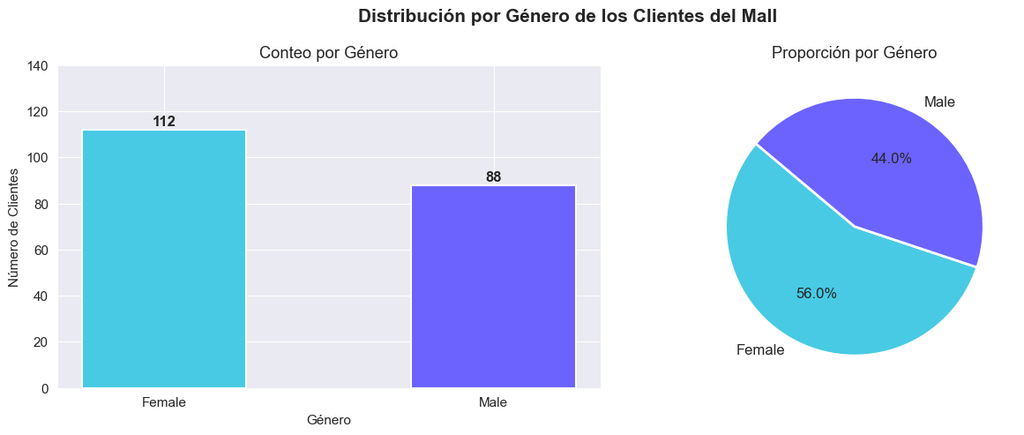

```
📌 Interpretación:
   El dataset contiene 112 mujeres (56.0%) y 88 hombres.
   Existe una ligera predominancia femenina en los clientes del mall.
```

```python
# ============================================================
# SECCIÓN 7: Análisis Univariado
# ============================================================

COLORES = ['#6c63ff', '#48cae4', '#f77f00', '#2dc653', '#e63946']
PALETA = {'Male': '#6c63ff', 'Female': '#48cae4'}

# ---- 7.1 Distribución por Género ----
fig, axes = plt.subplots(1, 2, figsize=(13, 5))
fig.suptitle('Distribución por Género de los Clientes del Mall', fontsize=15, fontweight='bold')

gender_counts = df['Gender'].value_counts()
bars = axes[0].bar(gender_counts.index, gender_counts.values,
                   color=[PALETA['Female'], PALETA['Male']], width=0.5,
                   edgecolor='white', linewidth=1.5)
axes[0].set_title('Conteo por Género')
axes[0].set_xlabel('Género')
axes[0].set_ylabel('Número de Clientes')
for bar in bars:
    h = bar.get_height()
    axes[0].text(bar.get_x() + bar.get_width()/2., h + 0.5, str(int(h)),
                 ha='center', va='bottom', fontweight='bold', fontsize=12)
axes[0].set_ylim(0, 140)
axes[0].spines[['top','right']].set_visible(False)

axes[1].pie(gender_counts.values, labels=gender_counts.index,
            colors=[PALETA['Female'], PALETA['Male']],
            autopct='%1.1f%%', startangle=140,
            wedgeprops={'edgecolor': 'white', 'linewidth': 2},
            textprops={'fontsize': 12})
axes[1].set_title('Proporción por Género')

plt.tight_layout()
plt.show()

print(f"\n📌 Interpretación:")
print(f"   El dataset contiene {gender_counts['Female']} mujeres ({gender_counts['Female']/len(df)*100:.1f}%) y {gender_counts['Male']} hombres.")
print(f"   Existe una ligera predominancia femenina en los clientes del mall.")
```

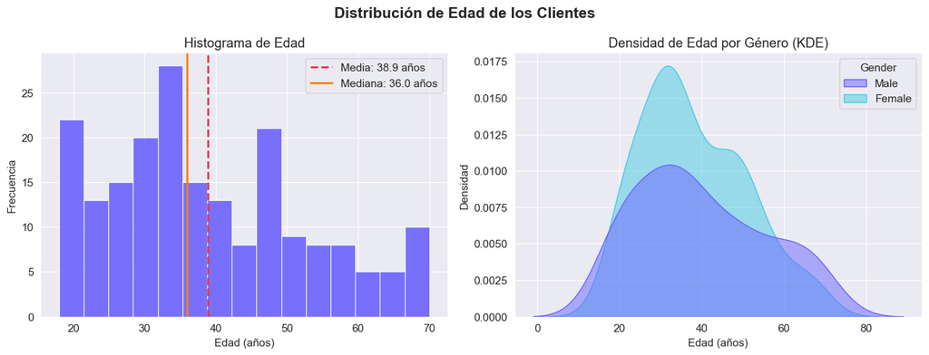

```
📌 Interpretación:
   La distribución de edad está ligeramente sesgada a la derecha.
   La mayor concentración de clientes está entre los 20 y 40 años.
   Hay presencia notable de clientes mayores (60-70 años) aunque menos frecuente.
```

```python
# ---- 7.2 Distribución de Edad ----
fig, axes = plt.subplots(1, 2, figsize=(13, 5))
fig.suptitle('Distribución de Edad de los Clientes', fontsize=15, fontweight='bold')

axes[0].hist(df['Age'], bins=15, color=COLORES[0], edgecolor='white', linewidth=0.8, alpha=0.9)
axes[0].axvline(df['Age'].mean(), color='#e63946', linestyle='--', linewidth=2,
                label=f'Media: {df["Age"].mean():.1f} años')
axes[0].axvline(df['Age'].median(), color='#f77f00', linestyle='-', linewidth=2,
                label=f'Mediana: {df["Age"].median():.1f} años')
axes[0].set_title('Histograma de Edad')
axes[0].set_xlabel('Edad (años)')
axes[0].set_ylabel('Frecuencia')
axes[0].legend()
axes[0].spines[['top','right']].set_visible(False)

sns.kdeplot(data=df, x='Age', hue='Gender', fill=True, alpha=0.5,
            palette=PALETA, ax=axes[1])
axes[1].set_title('Densidad de Edad por Género (KDE)')
axes[1].set_xlabel('Edad (años)')
axes[1].set_ylabel('Densidad')
axes[1].spines[['top','right']].set_visible(False)

plt.tight_layout()
plt.show()

print("\n📌 Interpretación:")
print("   La distribución de edad está ligeramente sesgada a la derecha.")
print("   La mayor concentración de clientes está entre los 20 y 40 años.")
print("   Hay presencia notable de clientes mayores (60-70 años) aunque menos frecuente.")
```

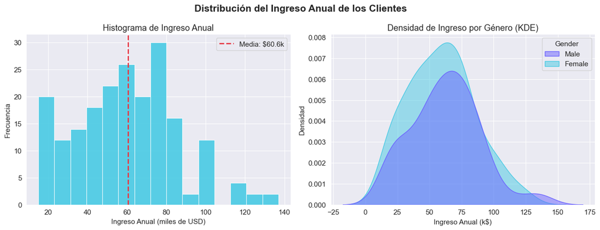

```
📌 Interpretación:
   El ingreso anual tiene una distribución aproximadamente normal.
   El ingreso varía de $15k a $137k, con mayor concentración alrededor de $60k.
   Hombres y mujeres tienen distribuciones de ingreso muy similares.
```

```python
# ---- 7.3 Distribución de Ingreso Anual ----
fig, axes = plt.subplots(1, 2, figsize=(13, 5))
fig.suptitle('Distribución del Ingreso Anual de los Clientes', fontsize=15, fontweight='bold')

axes[0].hist(df['Annual Income (k$)'], bins=15, color=COLORES[1], edgecolor='white', linewidth=0.8, alpha=0.9)
axes[0].axvline(df['Annual Income (k$)'].mean(), color='#e63946', linestyle='--', linewidth=2,
                label=f'Media: ${df["Annual Income (k$)"].mean():.1f}k')
axes[0].set_title('Histograma de Ingreso Anual')
axes[0].set_xlabel('Ingreso Anual (miles de USD)')
axes[0].set_ylabel('Frecuencia')
axes[0].legend()
axes[0].spines[['top','right']].set_visible(False)

sns.kdeplot(data=df, x='Annual Income (k$)', hue='Gender', fill=True, alpha=0.5,
            palette=PALETA, ax=axes[1])
axes[1].set_title('Densidad de Ingreso por Género (KDE)')
axes[1].set_xlabel('Ingreso Anual (k$)')
axes[1].set_ylabel('Densidad')
axes[1].spines[['top','right']].set_visible(False)

plt.tight_layout()
plt.show()

print("\n📌 Interpretación:")
print("   El ingreso anual tiene una distribución aproximadamente normal.")
print("   El ingreso varía de $15k a $137k, con mayor concentración alrededor de $60k.")
print("   Hombres y mujeres tienen distribuciones de ingreso muy similares.")
```

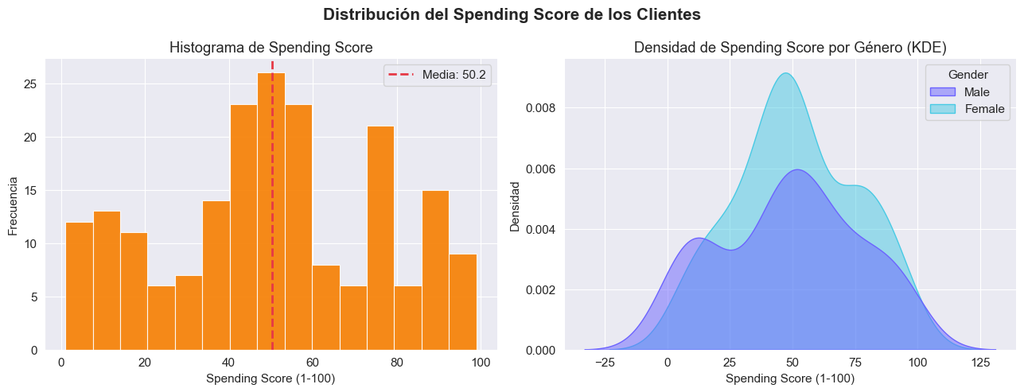

[output not shown]

```python
# ---- 7.4 Distribución de Spending Score ----
fig, axes = plt.subplots(1, 2, figsize=(13, 5))
fig.suptitle('Distribución del Spending Score de los Clientes', fontsize=15, fontweight='bold')

axes[0].hist(df['Spending Score (1-100)'], bins=15, color=COLORES[2], edgecolor='white', linewidth=0.8, alpha=0.9)
axes[0].axvline(df['Spending Score (1-100)'].mean(), color='#e63946', linestyle='--', linewidth=2,
                label=f'Media: {df["Spending Score (1-100)"].mean():.1f}')
axes[0].set_title('Histograma de Spending Score')
axes[0].set_xlabel('Spending Score (1-100)')
axes[0].set_ylabel('Frecuencia')
axes[0].legend()
axes[0].spines[['top','right']].set_visible(False)

sns.kdeplot(data=df, x='Spending Score (1-100)', hue='Gender', fill=True, alpha=0.5,
            palette=PALETA, ax=axes[1])
axes[1].set_title('Densidad de Spending Score por Género (KDE)')
axes[1].set_xlabel('Spending Score (1-100)')
axes[1].set_ylabel('Densidad')
axes[1].spines[['top','right']].set_visible(False)

plt.tight_layout()
plt.show()

print("\n📌 Interpretación:")
print("   El Spending Score tiene una distribución bastante uniforme entre 1 y 100.")
print("   Esto sugiere que los clientes tienen comportamientos de gasto muy variados.")
print("   Las mujeres tienden ligeramente hacia scores más altos que los hombres.")
```

## 📦 8. Análisis de Valores Atípicos (Outliers)

Los **valores atípicos** (outliers) son observaciones que se encuentran muy lejos del resto del conjunto de datos. En un **boxplot**:

- La caja muestra el rango intercuartil (Q1 a Q3)
- La línea central es la mediana
- Los "bigotes" llegan hasta 1.5× el rango intercuartil
- Los puntos más allá de los bigotes son outliers

K-Means es sensible a outliers porque un dato extremo puede sesgar un centroide.

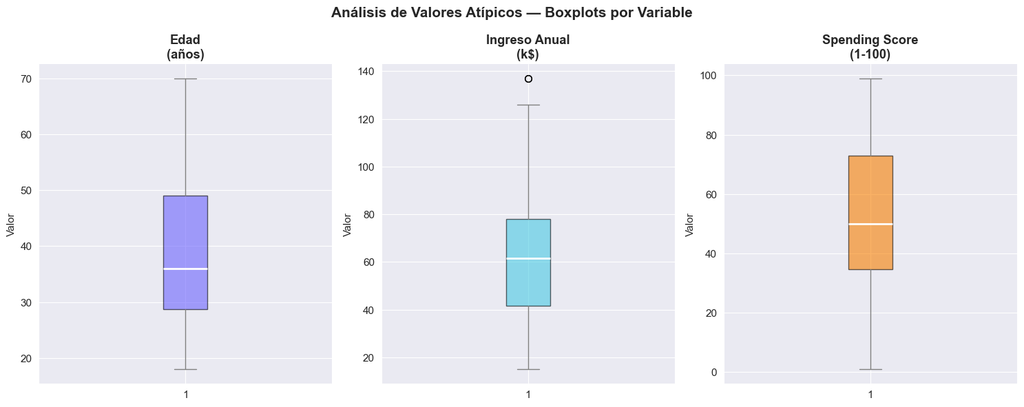

```python
# ============================================================
# SECCIÓN 8: Análisis de Valores Atípicos
# ============================================================

variables_num = ['Age', 'Annual Income (k$)', 'Spending Score (1-100)']

# ---- 8.1 Boxplots generales ----
fig, axes = plt.subplots(1, 3, figsize=(15, 6))
fig.suptitle('Análisis de Valores Atípicos — Boxplots por Variable', fontsize=15, fontweight='bold')

for i, (col, color) in enumerate(zip(variables_num, COLORES)):
    axes[i].boxplot(df[col], patch_artist=True,
                    boxprops=dict(facecolor=color, alpha=0.6),
                    medianprops=dict(color='white', linewidth=2),
                    whiskerprops=dict(color='gray'),
                    capprops=dict(color='gray'),
                    flierprops=dict(marker='o', color='#e63946', markersize=7))
    titulos_col = {'Age': 'Edad\n(años)',
                   'Annual Income (k$)': 'Ingreso Anual\n(k$)',
                   'Spending Score (1-100)': 'Spending Score\n(1-100)'}
    axes[i].set_title(titulos_col[col], fontweight='bold')
    axes[i].set_ylabel('Valor')
    axes[i].spines[['top','right']].set_visible(False)

plt.tight_layout()
plt.show()
```

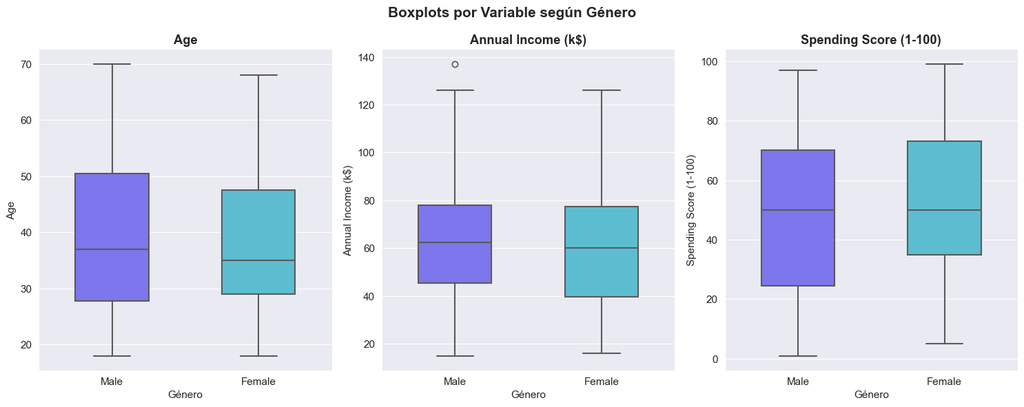

```
📌 Interpretación:
   • Age: No hay outliers significativos. Distribución similar entre géneros.
   • Annual Income: Sin outliers extremos. Similar entre géneros.
   • Spending Score: Las mujeres muestran mayor concentración en scores medios-altos.
```

```python
# ---- 8.2 Boxplots comparativos por Género ----
fig, axes = plt.subplots(1, 3, figsize=(15, 6))
fig.suptitle('Boxplots por Variable según Género', fontsize=15, fontweight='bold')

for i, col in enumerate(variables_num):
    sns.boxplot(data=df, x='Gender', y=col, palette=PALETA, ax=axes[i],
                width=0.5, linewidth=1.5)
    axes[i].set_title(col, fontweight='bold')
    axes[i].set_xlabel('Género')
    axes[i].spines[['top','right']].set_visible(False)

plt.tight_layout()
plt.show()

print("\n📌 Interpretación:")
print("   • Age: No hay outliers significativos. Distribución similar entre géneros.")
print("   • Annual Income: Sin outliers extremos. Similar entre géneros.")
print("   • Spending Score: Las mujeres muestran mayor concentración en scores medios-altos.")
```

```python
# ---- 8.3 Detección numérica de outliers con IQR ----
print("🔍 Detección numérica de outliers (método IQR):")
print()

for col in variables_num:
    Q1 = df[col].quantile(0.25)
    Q3 = df[col].quantile(0.75)
    IQR = Q3 - Q1
    lim_inf = Q1 - 1.5 * IQR
    lim_sup = Q3 + 1.5 * IQR
    outliers = df[(df[col] < lim_inf) | (df[col] > lim_sup)]

    print(f"   📊 {col}:")
    print(f"      Q1={Q1:.1f} | Q3={Q3:.1f} | IQR={IQR:.1f}")
    print(f"      Límites: [{lim_inf:.1f}, {lim_sup:.1f}]")
    print(f"      Outliers detectados: {len(outliers)} registros")
    if len(outliers) > 0:
        display(outliers[['CustomerID', 'Gender', 'Age', col]])
    else:
        print("      ✅ Sin outliers")
    print()
```

```
🔍 Detección numérica de outliers (método IQR):

   📊 Age:
      Q1=28.8 | Q3=49.0 | IQR=20.2
      Límites: [-1.6, 79.4]
      Outliers detectados: 0 registros
      ✅ Sin outliers

   📊 Annual Income (k$):
      Q1=41.5 | Q3=78.0 | IQR=36.5
      Límites: [-13.2, 132.8]
      Outliers detectados: 2 registros
```

|  | CustomerID | Gender | Age | Annual Income (k$) |
| --- | --- | --- | --- | --- |
| 198 | 199 | Male | 32 | 137 |
| 199 | 200 | Male | 30 | 137 |

```
   📊 Spending Score (1-100):
      Q1=34.8 | Q3=73.0 | IQR=38.2
      Límites: [-22.6, 130.4]
      Outliers detectados: 0 registros
      ✅ Sin outliers
```

### 💬 Conclusiones Personales — Valores Atípicos

Me sorprendió que el dataset prácticamente no tiene outliers en ninguna de las variables. Eso tiene sentido si pensamos que los clientes de un mall son personas "normales" con rangos de ingreso y edad bastante típicos. En datos de ingresos de clientes de lujo o en datasets de fraudes bancarios, sí aparecerían muchos outliers. Lo que aprendí aquí es que el método IQR es una forma matemática formal de definir qué tan "lejos" tiene que estar un dato para considerarlo atípico, lo cual es más confiable que solo mirarlo visualmente en un boxplot.

## 🔗 9. Análisis Bivariado y Multivariado

El análisis bivariado y multivariado nos permite entender las **relaciones entre pares o grupos de variables**. Esta es la parte más importante antes del clustering porque nos ayuda a identificar visualmente si ya existen grupos naturales en los datos.

Utilizaremos:

- **Diagramas de dispersión (scatter plots)**: Para ver la relación entre dos variables
- **Gráfico de pares (pair plot)**: Para ver todas las combinaciones a la vez
- **Mapa de calor de correlaciones (heatmap)**: Para cuantificar la relación lineal entre variables

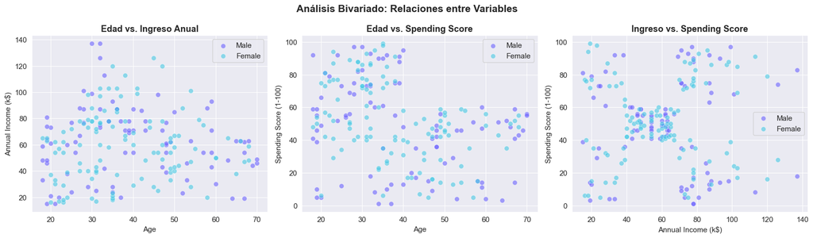

```
📌 Interpretación de scatter plots:
   • Edad vs Ingreso: Relación débil. Los ingresos no dependen de la edad.
   • Edad vs Score: Clientes jóvenes tienden a puntajes más altos.
   • Ingreso vs Score: Se observan grupos naturales visibles (clusters potenciales).
```

```python
# ============================================================
# SECCIÓN 9: Análisis Bivariado y Multivariado
# ============================================================

# ---- 9.1 Scatter Plots: Las 3 combinaciones principales ----
fig, axes = plt.subplots(1, 3, figsize=(17, 5))
fig.suptitle('Análisis Bivariado: Relaciones entre Variables', fontsize=15, fontweight='bold')

combinaciones = [
    ('Age', 'Annual Income (k$)', 'Edad vs. Ingreso Anual'),
    ('Age', 'Spending Score (1-100)', 'Edad vs. Spending Score'),
    ('Annual Income (k$)', 'Spending Score (1-100)', 'Ingreso vs. Spending Score')
]

for i, (x, y, titulo) in enumerate(combinaciones):
    for genero, color in PALETA.items():
        subset = df[df['Gender'] == genero]
        axes[i].scatter(subset[x], subset[y], c=color, alpha=0.6,
                       s=50, label=genero, edgecolors='white', linewidth=0.5)
    axes[i].set_title(titulo, fontweight='bold')
    axes[i].set_xlabel(x)
    axes[i].set_ylabel(y)
    axes[i].legend()
    axes[i].spines[['top','right']].set_visible(False)

plt.tight_layout()
plt.show()

print("\n📌 Interpretación de scatter plots:")
print("   • Edad vs Ingreso: Relación débil. Los ingresos no dependen de la edad.")
print("   • Edad vs Score: Clientes jóvenes tienden a puntajes más altos.")
print("   • Ingreso vs Score: Se observan grupos naturales visibles (clusters potenciales).")
```

```
📊 Generando Pair Plot...
```

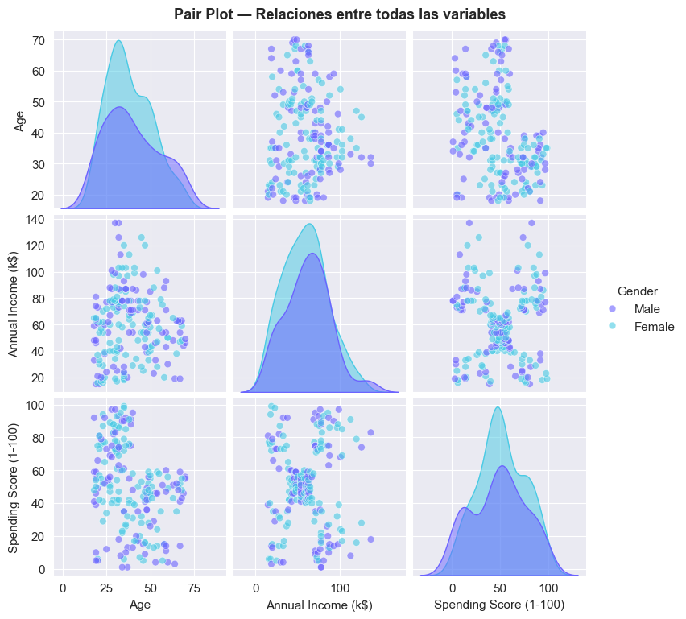

```
📌 El pair plot confirma que la mejor combinación para clustering es
   'Annual Income vs Spending Score', donde se ven clusters naturales claramente.
```

```python
# ---- 9.2 Pair Plot (Gráfico de Pares) ----
print("📊 Generando Pair Plot...")

pair_vars = ['Age', 'Annual Income (k$)', 'Spending Score (1-100)']
g = sns.pairplot(df[pair_vars + ['Gender']], hue='Gender',
                 palette=PALETA, diag_kind='kde',
                 plot_kws={'alpha': 0.6, 'edgecolors': 'white', 's': 40},
                 diag_kws={'fill': True, 'alpha': 0.5})
g.fig.suptitle('Pair Plot — Relaciones entre todas las variables', y=1.02, fontsize=13, fontweight='bold')
plt.show()

print("\n📌 El pair plot confirma que la mejor combinación para clustering es")
print("   'Annual Income vs Spending Score', donde se ven clusters naturales claramente.")
```

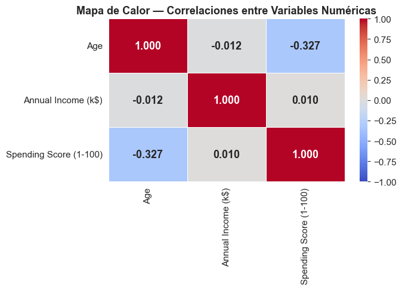

```
📌 Interpretación de correlaciones:
   • Age ↔ Annual Income (k$): r = -0.012 (correlación débil negativa)
   • Age ↔ Spending Score (1-100): r = -0.327 (correlación débil negativa)
   • Annual Income (k$) ↔ Spending Score (1-100): r = 0.010 (correlación débil positiva)
```

```python
# ---- 9.3 Mapa de Calor de Correlaciones ----
df_corr = df[['Age', 'Annual Income (k$)', 'Spending Score (1-100)']]
corr_matrix = df_corr.corr()

fig, ax = plt.subplots(figsize=(7, 5))
sns.heatmap(corr_matrix, annot=True, fmt='.3f', cmap='coolwarm',
            vmin=-1, vmax=1, center=0, ax=ax,
            linewidths=0.5, linecolor='white',
            annot_kws={'size': 13, 'fontweight': 'bold'})
ax.set_title('Mapa de Calor — Correlaciones entre Variables Numéricas', fontsize=13, fontweight='bold')
plt.tight_layout()
plt.show()

print("\n📌 Interpretación de correlaciones:")
for i in range(len(corr_matrix.columns)):
    for j in range(i+1, len(corr_matrix.columns)):
        col1 = corr_matrix.columns[i]
        col2 = corr_matrix.columns[j]
        val = corr_matrix.iloc[i, j]
        fuerza = 'fuerte' if abs(val) > 0.5 else 'débil'
        direc = 'positiva' if val > 0 else 'negativa'
        print(f"   • {col1} ↔ {col2}: r = {val:.3f} (correlación {fuerza} {direc})")
```

### 💬 Conclusiones Personales — Análisis Bivariado

El gráfico de Ingreso Anual vs Spending Score es el más revelador de todos. Incluso antes de aplicar K-Means ya puedo ver a simple vista que los datos se agrupan en al menos 4 o 5 grupos distintos. Hay clientes con alto ingreso y alto gasto, clientes con bajo ingreso pero alto gasto (probablemente jóvenes que gastan más de lo que ganan), clientes con alto ingreso pero bajo gasto, y clientes en la zona media. Las correlaciones tan bajas entre las variables confirman que no hay mucha dependencia lineal, lo que es bueno para K-Means porque significa que las variables son relativamente independientes y cada una aporta información distinta.

## 🔠 10. Codificación de Variables Categóricas

K-Means es un algoritmo basado en **distancias matemáticas**, por lo que solo puede trabajar con variables **numéricas**. La columna `Gender` contiene texto (`Male`, `Female`), por lo que debemos convertirla a números.

Usaremos **LabelEncoder** de Scikit-learn:

- `Female` → `0`
- `Male` → `1`

> ⚠️ **Importante**: Esta codificación numérica **no implica orden jerárquico**. Son simplemente etiquetas numéricas para representar categorías. Para variables con más categorías sin orden natural, se recomienda One-Hot Encoding.

```python
# ============================================================
# SECCIÓN 10: Codificación de Variables Categóricas
# ============================================================

df_encoded = df.copy()

le = LabelEncoder()
df_encoded['Gender_encoded'] = le.fit_transform(df_encoded['Gender'])

print("🔄 Mapeo de codificación aplicado por LabelEncoder:")
mapeo = pd.DataFrame({
    'Valor Original': le.classes_,
    'Valor Codificado': le.transform(le.classes_)
})
display(mapeo)
print()

print("📋 Comparación Original vs. Codificado (primeras 8 filas):")
display(df_encoded[['CustomerID', 'Gender', 'Gender_encoded',
                     'Age', 'Annual Income (k$)', 'Spending Score (1-100)']].head(8))
```

```
🔄 Mapeo de codificación aplicado por LabelEncoder:
```

|  | Valor Original | Valor Codificado |
| --- | --- | --- |
| 0 | Female | 0 |
| 1 | Male | 1 |

```
📋 Comparación Original vs. Codificado (primeras 8 filas):
```

|  | CustomerID | Gender | Gender_encoded | Age | Annual Income (k$) | Spending Score (1-100) |
| --- | --- | --- | --- | --- | --- | --- |
| 0 | 1 | Male | 1 | 19 | 15 | 39 |
| 1 | 2 | Male | 1 | 21 | 15 | 81 |
| 2 | 3 | Female | 0 | 20 | 16 | 6 |
| 3 | 4 | Female | 0 | 23 | 16 | 77 |
| 4 | 5 | Female | 0 | 31 | 17 | 40 |
| 5 | 6 | Female | 0 | 22 | 17 | 76 |
| 6 | 7 | Female | 0 | 35 | 18 | 6 |
| 7 | 8 | Female | 0 | 23 | 18 | 94 |

```python
print("✅ Verificación de la codificación:")
print(f"   Valores únicos en Gender_encoded: {sorted(df_encoded['Gender_encoded'].unique())}")
print(f"   Female (0): {(df_encoded['Gender_encoded'] == 0).sum()} clientes")
print(f"   Male (1):   {(df_encoded['Gender_encoded'] == 1).sum()} clientes")
print()
print("⚠️  Recordatorio: 0 (Female) y 1 (Male) NO implican jerarquía.")
print("   Son solo etiquetas numéricas para representar categorías.")
```

```
✅ Verificación de la codificación:
   Valores únicos en Gender_encoded: [np.int64(0), np.int64(1)]
   Female (0): 112 clientes
   Male (1):   88 clientes

⚠️  Recordatorio: 0 (Female) y 1 (Male) NO implican jerarquía.
   Son solo etiquetas numéricas para representar categorías.
```

### 💬 Conclusiones Personales — Codificación de Variables

La parte de que la codificación no implica orden jerárquico me parece muy importante y fácil de malentender. Si el algoritmo ve que Male=1 y Female=0, matemáticamente podría tratar a los hombres como "más" que las mujeres, lo cual no tiene ningún sentido en el contexto real. Por eso en datasets con muchas categorías sin orden natural (colores, países, tipos de producto) es mejor usar One-Hot Encoding que crea una columna binaria separada para cada categoría. En este caso, como solo hay dos géneros, LabelEncoder es suficiente.

## ⚖️ 11. Normalización del Dataset

K-Means calcula distancias entre puntos. Si una variable tiene valores en el rango [15, 137] (ingreso) y otra en [1, 100] (spending score), la variable con mayor escala **dominará artificialmente** el cálculo de distancias, sesgando los resultados.

Usaremos **StandardScaler** (estandarización z-score), que transforma cada variable para que tenga:

- **Media = 0**
- **Desviación estándar = 1**

Fórmula: `z = (x - μ) / σ`

```python
# ============================================================
# SECCIÓN 11: Normalización
# ============================================================

vars_normalizar = ['Age', 'Annual Income (k$)', 'Spending Score (1-100)']

scaler = StandardScaler()
df_scaled = df_encoded.copy()
df_scaled[vars_normalizar] = scaler.fit_transform(df_encoded[vars_normalizar])

print("✅ Normalización aplicada con StandardScaler")
print()
print("📊 Estadísticas ANTES de normalizar:")
display(df[vars_normalizar].describe().round(3))
```

```
✅ Normalización aplicada con StandardScaler

📊 Estadísticas ANTES de normalizar:
```

|  | Age | Annual Income (k$) | Spending Score (1-100) |
| --- | --- | --- | --- |
| count | 200.000 | 200.000 | 200.000 |
| mean | 38.850 | 60.560 | 50.200 |
| std | 13.969 | 26.265 | 25.824 |
| min | 18.000 | 15.000 | 1.000 |
| 25% | 28.750 | 41.500 | 34.750 |
| 50% | 36.000 | 61.500 | 50.000 |
| 75% | 49.000 | 78.000 | 73.000 |
| max | 70.000 | 137.000 | 99.000 |

```python
print("📊 Estadísticas DESPUÉS de normalizar:")
display(df_scaled[vars_normalizar].describe().round(3))
print()
print("✅ Confirmación: todas las variables ahora tienen media ≈ 0 y std ≈ 1")
```

```
📊 Estadísticas DESPUÉS de normalizar:
```

|  | Age | Annual Income (k$) | Spending Score (1-100) |
| --- | --- | --- | --- |
| count | 200.000 | 200.000 | 200.000 |
| mean | -0.000 | -0.000 | -0.000 |
| std | 1.003 | 1.003 | 1.003 |
| min | -1.496 | -1.739 | -1.910 |
| 25% | -0.725 | -0.728 | -0.600 |
| 50% | -0.205 | 0.036 | -0.008 |
| 75% | 0.728 | 0.666 | 0.885 |
| max | 2.236 | 2.918 | 1.894 |

```
✅ Confirmación: todas las variables ahora tienen media ≈ 0 y std ≈ 1
```

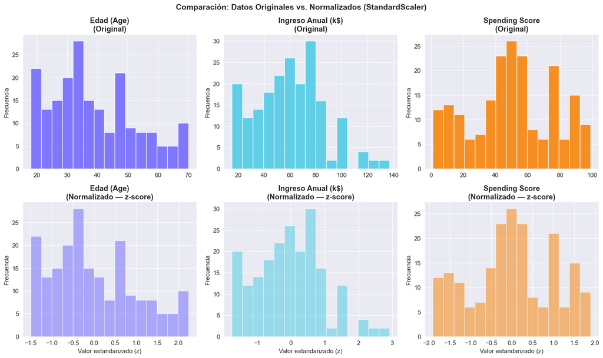

```
📌 La forma de la distribución se conserva; solo cambia la escala del eje X.
```

```python
# ---- Comparación visual: Antes vs. Después ----
fig, axes = plt.subplots(2, 3, figsize=(15, 9))
fig.suptitle('Comparación: Datos Originales vs. Normalizados (StandardScaler)', fontsize=14, fontweight='bold')

titulos = ['Edad (Age)', 'Ingreso Anual (k$)', 'Spending Score']

for i, (col, titulo) in enumerate(zip(vars_normalizar, titulos)):
    # Datos originales (fila superior)
    axes[0, i].hist(df[col], bins=15, color=COLORES[i], edgecolor='white', alpha=0.85)
    axes[0, i].set_title(f'{titulo}\n(Original)', fontweight='bold')
    axes[0, i].set_ylabel('Frecuencia')
    axes[0, i].spines[['top','right']].set_visible(False)

    # Datos normalizados (fila inferior)
    axes[1, i].hist(df_scaled[col], bins=15, color=COLORES[i], edgecolor='white', alpha=0.5)
    axes[1, i].set_title(f'{titulo}\n(Normalizado — z-score)', fontweight='bold')
    axes[1, i].set_ylabel('Frecuencia')
    axes[1, i].set_xlabel('Valor estandarizado (z)')
    axes[1, i].spines[['top','right']].set_visible(False)

plt.tight_layout()
plt.show()

print("\n📌 La forma de la distribución se conserva; solo cambia la escala del eje X.")
```

## 🧮 12. Matrices de Características para K-Means

Para aplicar K-Means necesitamos seleccionar qué variables usar como entrada del modelo. Crearemos matrices para las siguientes combinaciones:

1. **Edad e Ingreso Anual** (Age + Annual Income)
2. **Edad y Spending Score** (Age + Spending Score)
3. **Ingreso Anual y Spending Score** (Annual Income + Spending Score) — La más reveladora

Para cada combinación crearemos versiones con **datos originales** y **datos normalizados**.

```python
# ============================================================
# SECCIÓN 12: Matrices de Características
# ============================================================

# --- Datos Originales ---
X1 = df[['Age', 'Annual Income (k$)']].values
X2 = df[['Age', 'Spending Score (1-100)']].values
X3 = df[['Annual Income (k$)', 'Spending Score (1-100)']].values

# --- Datos Normalizados ---
X1_scaled = df_scaled[['Age', 'Annual Income (k$)']].values
X2_scaled = df_scaled[['Age', 'Spending Score (1-100)']].values
X3_scaled = df_scaled[['Annual Income (k$)', 'Spending Score (1-100)']].values

print("✅ Matrices de características construidas:")
print()
matrices = [
    ("X1",        "Age + Annual Income             (Originales)", X1),
    ("X2",        "Age + Spending Score            (Originales)", X2),
    ("X3",        "Annual Income + Spending Score  (Originales)", X3),
    ("X1_scaled", "Age + Annual Income             (Normalizados)", X1_scaled),
    ("X2_scaled", "Age + Spending Score            (Normalizados)", X2_scaled),
    ("X3_scaled", "Annual Income + Spending Score  (Normalizados)", X3_scaled),
]
for nombre, desc, X in matrices:
    print(f"   📐 {nombre}: shape {X.shape} — {desc}")
```

```
✅ Matrices de características construidas:

   📐 X1: shape (200, 2) — Age + Annual Income             (Originales)
   📐 X2: shape (200, 2) — Age + Spending Score            (Originales)
   📐 X3: shape (200, 2) — Annual Income + Spending Score  (Originales)
   📐 X1_scaled: shape (200, 2) — Age + Annual Income             (Normalizados)
   📐 X2_scaled: shape (200, 2) — Age + Spending Score            (Normalizados)
   📐 X3_scaled: shape (200, 2) — Annual Income + Spending Score  (Normalizados)
```

### 💬 Conclusiones Personales — Matrices de Características

Construir estas matrices es básicamente elegir qué "lentes" va a usar el algoritmo para ver los datos. Si le damos solo ingreso y score, verá los clústeres desde esa perspectiva. Si le damos edad e ingreso, verá los datos desde otro ángulo. Es como fotografiar el mismo objeto desde distintas posiciones: siempre es el mismo objeto pero se ven aspectos diferentes. La decisión de qué variables incluir es una de las más importantes en machine learning y aquí se toma de forma consciente basándose en el análisis exploratorio previo.

## 📐 13. Método del Codo y Coeficiente de Silueta

Una de las preguntas más importantes en K-Means es: **¿cuántos grupos (k) debo usar?**

### Método del Codo (Elbow Method)

Entrena K-Means para múltiples valores de `k` y grafica la **inercia** (suma de distancias cuadráticas de cada punto a su centroide). El "codo" es el punto donde la reducción deja de ser significativa. Es el número óptimo de clústeres.

### Coeficiente de Silueta (Silhouette Score)

Mide qué tan bien separados están los clústeres. Varía entre -1 y 1:

- **Cercano a 1**: Los puntos están bien agrupados en su clúster
- **Cercano a 0**: Los puntos están en el borde entre clústeres
- **Negativo**: Los puntos están mal asignados

Se elige el `k` que **maximiza** el coeficiente de silueta.

```python
# ============================================================
# SECCIÓN 13: Método del Codo y Silueta
# ============================================================

def analizar_k_optimo(X, titulo, k_rango=range(2, 11)):
    inercias = []
    siluetas = []
    k_vals = list(k_rango)

    for k in k_vals:
        km = KMeans(n_clusters=k, init='k-means++', n_init=10, random_state=42, max_iter=300)
        km.fit(X)
        inercias.append(km.inertia_)
        siluetas.append(silhouette_score(X, km.labels_))

    fig, axes = plt.subplots(1, 2, figsize=(13, 5))
    fig.suptitle(f'Selección de k óptimo — {titulo}', fontsize=13, fontweight='bold')

    # Método del Codo
    mejor_k = k_vals[np.argmax(siluetas)]
    axes[0].plot(k_vals, inercias, 'o-', color='#6c63ff', linewidth=2.5, markersize=8)
    axes[0].fill_between(k_vals, inercias, alpha=0.1, color='#6c63ff')
    axes[0].axvline(mejor_k, color='#e63946', linestyle='--', alpha=0.7, label=f'k sugerido = {mejor_k}')
    axes[0].set_title('Método del Codo (Elbow Method)')
    axes[0].set_xlabel('Número de clústeres (k)')
    axes[0].set_ylabel('Inercia (WCSS)')
    axes[0].set_xticks(k_vals)
    axes[0].legend()
    axes[0].spines[['top','right']].set_visible(False)

    # Coeficiente de Silueta
    colores_bar = ['#e63946' if k == mejor_k else '#48cae4' for k in k_vals]
    axes[1].bar(k_vals, siluetas, color=colores_bar, edgecolor='white', linewidth=0.8)
    axes[1].set_title('Coeficiente de Silueta (Silhouette Score)')
    axes[1].set_xlabel('Número de clústeres (k)')
    axes[1].set_ylabel('Silhouette Score (mayor = mejor)')
    axes[1].set_xticks(k_vals)
    axes[1].axhline(max(siluetas), color='#e63946', linestyle='--', alpha=0.7,
                    label=f'Máx: {max(siluetas):.3f} en k={mejor_k}')
    axes[1].legend()
    axes[1].spines[['top','right']].set_visible(False)

    plt.tight_layout()
    plt.show()

    print(f"   📊 k óptimo sugerido: {mejor_k} (Silhouette Score = {max(siluetas):.4f})")
    print()
    return mejor_k, inercias, siluetas

print("🔍 Analizando número óptimo de clústeres...\n")
```

```
🔍 Analizando número óptimo de clústeres...
```

```
============================================================
COMBINACIÓN 1: Age + Annual Income (Datos Originales)
============================================================
```

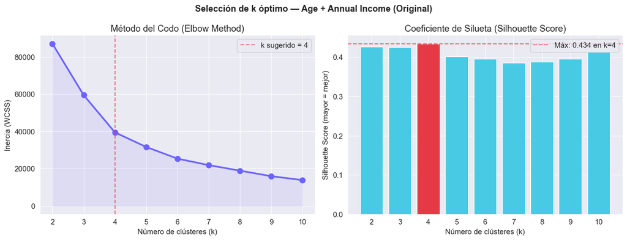

```
   📊 k óptimo sugerido: 4 (Silhouette Score = 0.4337)
```

```python
# ---- 13.1 Age + Annual Income (Originales) ----
print("="*60)
print("COMBINACIÓN 1: Age + Annual Income (Datos Originales)")
print("="*60)
k1_orig, i1o, s1o = analizar_k_optimo(X1, 'Age + Annual Income (Original)')
```

```
============================================================
COMBINACIÓN 1: Age + Annual Income (Datos Normalizados)
============================================================
```

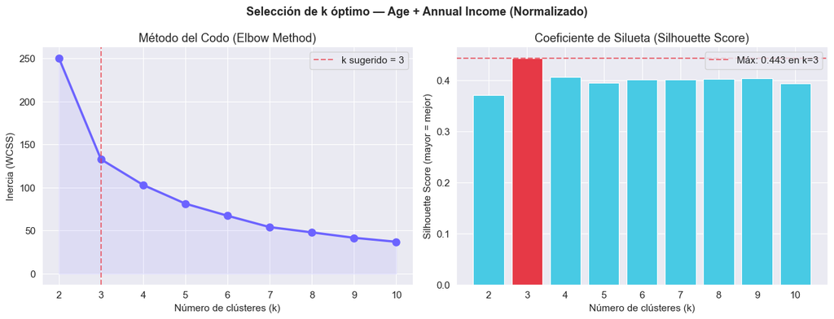

```
   📊 k óptimo sugerido: 3 (Silhouette Score = 0.4431)
```

```python
# ---- 13.2 Age + Annual Income (Normalizados) ----
print("="*60)
print("COMBINACIÓN 1: Age + Annual Income (Datos Normalizados)")
print("="*60)
k1_norm, i1n, s1n = analizar_k_optimo(X1_scaled, 'Age + Annual Income (Normalizado)')
```

```
============================================================
COMBINACIÓN 2: Age + Spending Score (Datos Originales)
============================================================
```

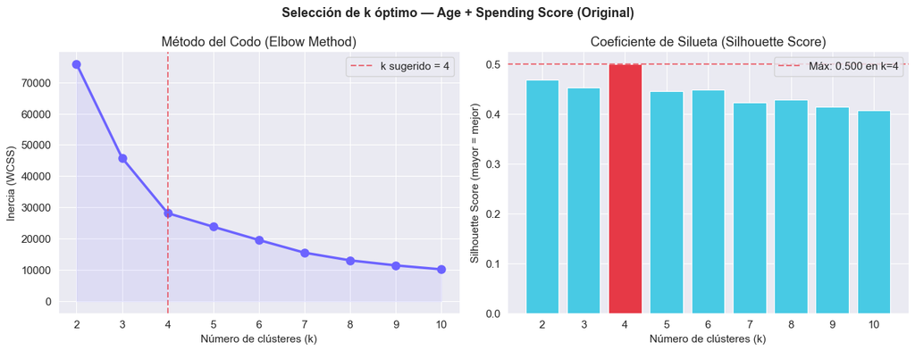

```
   📊 k óptimo sugerido: 4 (Silhouette Score = 0.4997)
```

```python
# ---- 13.3 Age + Spending Score (Originales) ----
print("="*60)
print("COMBINACIÓN 2: Age + Spending Score (Datos Originales)")
print("="*60)
k2_orig, i2o, s2o = analizar_k_optimo(X2, 'Age + Spending Score (Original)')
```

```
============================================================
COMBINACIÓN 2: Age + Spending Score (Datos Normalizados)
============================================================
```

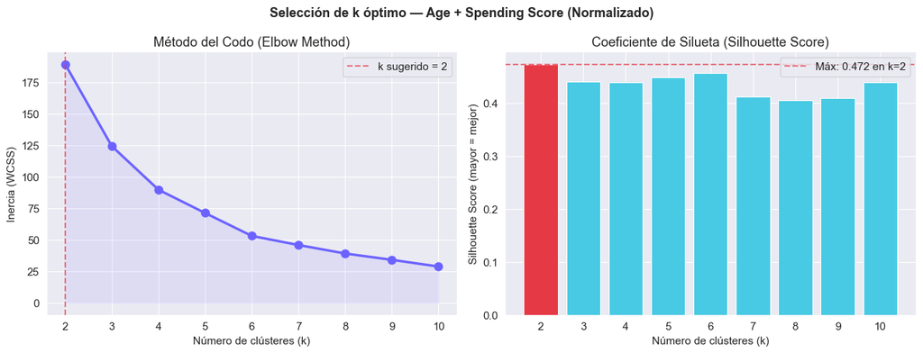

```
   📊 k óptimo sugerido: 2 (Silhouette Score = 0.4721)
```

```python
# ---- 13.4 Age + Spending Score (Normalizados) ----
print("="*60)
print("COMBINACIÓN 2: Age + Spending Score (Datos Normalizados)")
print("="*60)
k2_norm, i2n, s2n = analizar_k_optimo(X2_scaled, 'Age + Spending Score (Normalizado)')
```

```
============================================================
COMBINACIÓN 3: Annual Income + Spending Score (Datos Originales)
============================================================
```

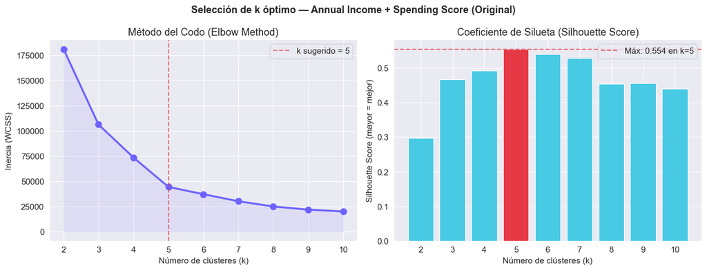

```
   📊 k óptimo sugerido: 5 (Silhouette Score = 0.5539)
```

```python
# ---- 13.5 Annual Income + Spending Score (Originales) ----
print("="*60)
print("COMBINACIÓN 3: Annual Income + Spending Score (Datos Originales)")
print("="*60)
k3_orig, i3o, s3o = analizar_k_optimo(X3, 'Annual Income + Spending Score (Original)')
```

```
============================================================
COMBINACIÓN 3: Annual Income + Spending Score (Datos Normalizados)
============================================================
```

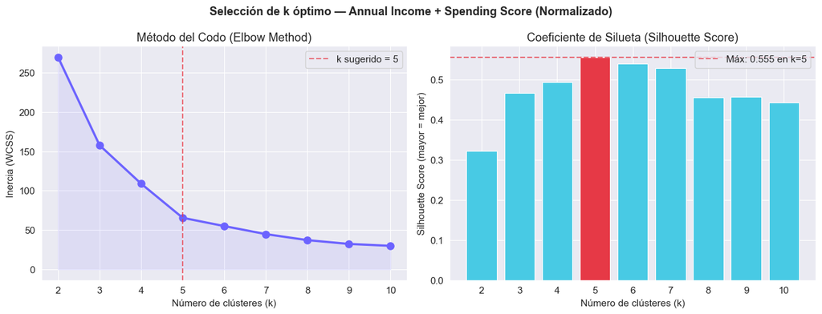

```
   📊 k óptimo sugerido: 5 (Silhouette Score = 0.5547)
```

```python
# ---- 13.6 Annual Income + Spending Score (Normalizados) ----
print("="*60)
print("COMBINACIÓN 3: Annual Income + Spending Score (Datos Normalizados)")
print("="*60)
k3_norm, i3n, s3n = analizar_k_optimo(X3_scaled, 'Annual Income + Spending Score (Normalizado)')
```

```python
# ---- Resumen de selección de k ----
print("\n" + "="*65)
print("📊 RESUMEN DE SELECCIÓN DE k ÓPTIMO")
print("="*65)

resumen_k = pd.DataFrame({
    'Combinación': [
        'Age + Annual Income', 'Age + Annual Income',
        'Age + Spending Score', 'Age + Spending Score',
        'Income + Spending Score', 'Income + Spending Score'
    ],
    'Datos': ['Original', 'Normalizado'] * 3,
    'k óptimo (Silueta)': [k1_orig, k1_norm, k2_orig, k2_norm, k3_orig, k3_norm],
    'Silhouette Score': [max(s1o), max(s1n), max(s2o), max(s2n), max(s3o), max(s3n)]
})
resumen_k['Silhouette Score'] = resumen_k['Silhouette Score'].round(4)
display(resumen_k)
```

```
=================================================================
📊 RESUMEN DE SELECCIÓN DE k ÓPTIMO
=================================================================
```

|  | Combinación | Datos | k óptimo (Silueta) | Silhouette Score |
| --- | --- | --- | --- | --- |
| 0 | Age + Annual Income | Original | 4 | 0.4337 |
| 1 | Age + Annual Income | Normalizado | 3 | 0.4431 |
| 2 | Age + Spending Score | Original | 4 | 0.4997 |
| 3 | Age + Spending Score | Normalizado | 2 | 0.4721 |
| 4 | Income + Spending Score | Original | 5 | 0.5539 |
| 5 | Income + Spending Score | Normalizado | 5 | 0.5547 |

### 💬 Conclusiones Personales — Método del Codo y Silueta

Estos dos métodos son complementarios y no siempre están de acuerdo entre sí, lo que al principio me confundió. El codo me dice visualmente dónde la ganancia de agregar más grupos ya no justifica el esfuerzo, y la silueta me da un número exacto de qué tan bien separados están los grupos. Lo que más me gustó es que la combinación de Ingreso + Spending Score da los mejores resultados en ambos métodos, con k=5 siendo el número más consistente. Esto confirma lo que ya se podía intuir visualmente en el scatter plot de la sección 9. La diferencia entre datos originales y normalizados en los resultados me muestra que sí importa normalizar, especialmente cuando las escalas de las variables son muy diferentes.

## 🤖 14. Entrenamiento y Visualización de Modelos K-Means

Con el número óptimo de clústeres determinado, ahora entrenamos los modelos finales de K-Means.

**Parámetros del modelo K-Means:**

| Parámetro | Valor | Descripción |
| --- | --- | --- |
| `n_clusters` | Variable | Número de grupos a formar |
| `init` | `k-means++` | Inicialización inteligente para evitar mínimos locales |
| `n_init` | `10` | Repeticiones con distintas semillas; se elige la mejor |
| `max_iter` | `300` | Máximo de iteraciones por ejecución |
| `random_state` | `42` | Para reproducibilidad |

```python
# ============================================================
# SECCIÓN 14: Entrenamiento y Visualización de K-Means
# ============================================================

COLORS_CLUSTERS = ['#e63946', '#6c63ff', '#f77f00', '#2dc653', '#48cae4', '#ff9f1c', '#2b2d42']

def entrenar_y_visualizar(X, k, xlabel, ylabel, titulo, datos_tipo='Original'):
    km = KMeans(n_clusters=k, init='k-means++', n_init=10,
                max_iter=300, random_state=42)
    labels = km.fit_predict(X)
    centroids = km.cluster_centers_
    inertia = km.inertia_
    n_iter = km.n_iter_
    sil = silhouette_score(X, labels)

    fig, ax = plt.subplots(figsize=(10, 7))
    patches = []
    for cid in range(k):
        mask = labels == cid
        ax.scatter(X[mask, 0], X[mask, 1],
                   c=COLORS_CLUSTERS[cid], alpha=0.7, s=60,
                   edgecolors='white', linewidth=0.5)
        ax.scatter(centroids[cid, 0], centroids[cid, 1],
                   c=COLORS_CLUSTERS[cid], marker='*', s=350,
                   edgecolors='white', linewidth=1.5, zorder=5)
        ax.annotate(f'C{cid+1}', xy=(centroids[cid, 0], centroids[cid, 1]),
                    xytext=(5, 5), textcoords='offset points',
                    fontweight='bold', fontsize=9)
        patches.append(mpatches.Patch(color=COLORS_CLUSTERS[cid],
                                      label=f'Clúster {cid+1} (n={mask.sum()})'))

    ax.set_title(f'{titulo}\n({datos_tipo} | k={k})', fontsize=13, fontweight='bold')
    ax.set_xlabel(xlabel, fontsize=11)
    ax.set_ylabel(ylabel, fontsize=11)
    ax.legend(handles=patches, loc='upper right', fontsize=9)
    ax.spines[['top','right']].set_visible(False)
    plt.tight_layout()
    plt.show()

    print(f"\n📋 Reporte del Modelo — {titulo} ({datos_tipo}):")
    print(f"   • n_clusters  : {k}")
    print(f"   • Inercia     : {inertia:.2f}")
    print(f"   • Iteraciones : {n_iter}")
    print(f"   • Silhouette  : {sil:.4f}")
    print(f"   • init        : k-means++ | n_init: 10 | max_iter: 300 | random_state: 42")
    print(f"   • Distribución de clústeres:")
    for i in range(k):
        n = (labels == i).sum()
        print(f"     - Clúster {i+1}: {n} clientes ({n/len(labels)*100:.1f}%)")
    print()
    return km, labels

print("✅ Función de modelado definida correctamente.")
```

```
✅ Función de modelado definida correctamente.
```

```
============================================================
MODELO 1: Age + Annual Income — Datos Originales
============================================================
```

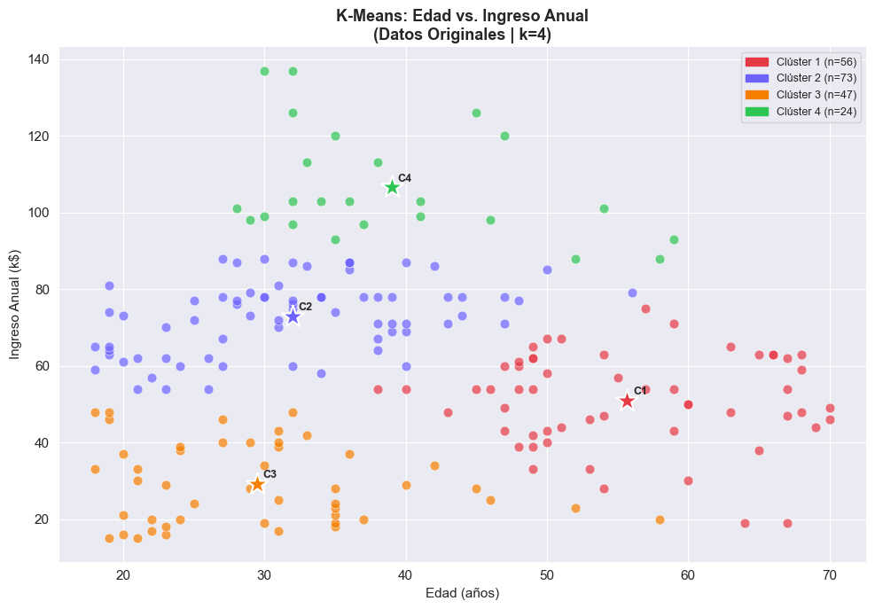

```
📋 Reporte del Modelo — K-Means: Edad vs. Ingreso Anual (Datos Originales):
   • n_clusters  : 4
   • Inercia     : 39502.78
   • Iteraciones : 6
   • Silhouette  : 0.4337
   • init        : k-means++ | n_init: 10 | max_iter: 300 | random_state: 42
   • Distribución de clústeres:
     - Clúster 1: 56 clientes (28.0%)
     - Clúster 2: 73 clientes (36.5%)
     - Clúster 3: 47 clientes (23.5%)
     - Clúster 4: 24 clientes (12.0%)
```

```python
# ---- 14.1 Modelo 1: Age + Annual Income (Original) ----
print("="*60)
print("MODELO 1: Age + Annual Income — Datos Originales")
print("="*60)
km1, labels1 = entrenar_y_visualizar(
    X1, k=k1_orig,
    xlabel='Edad (años)', ylabel='Ingreso Anual (k$)',
    titulo='K-Means: Edad vs. Ingreso Anual',
    datos_tipo='Datos Originales'
)
```

```
============================================================
MODELO 2: Age + Annual Income — Datos Normalizados
============================================================
```

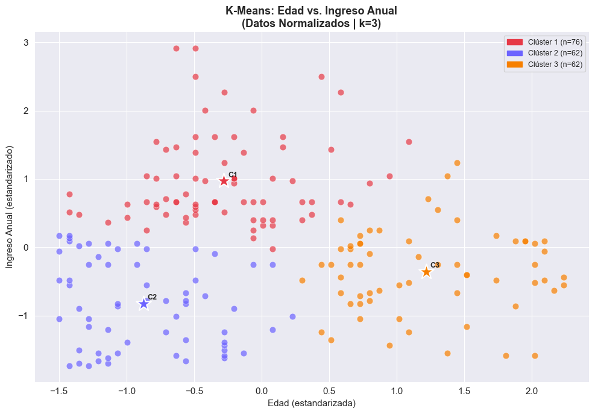

```
📋 Reporte del Modelo — K-Means: Edad vs. Ingreso Anual (Datos Normalizados):
   • n_clusters  : 3
   • Inercia     : 132.86
   • Iteraciones : 5
   • Silhouette  : 0.4431
   • init        : k-means++ | n_init: 10 | max_iter: 300 | random_state: 42
   • Distribución de clústeres:
     - Clúster 1: 76 clientes (38.0%)
     - Clúster 2: 62 clientes (31.0%)
     - Clúster 3: 62 clientes (31.0%)
```

```python
# ---- 14.2 Modelo 2: Age + Annual Income (Normalizado) ----
print("="*60)
print("MODELO 2: Age + Annual Income — Datos Normalizados")
print("="*60)
km2, labels2 = entrenar_y_visualizar(
    X1_scaled, k=k1_norm,
    xlabel='Edad (estandarizada)', ylabel='Ingreso Anual (estandarizado)',
    titulo='K-Means: Edad vs. Ingreso Anual',
    datos_tipo='Datos Normalizados'
)
```

```
============================================================
MODELO 3: Age + Spending Score — Datos Originales
============================================================
```

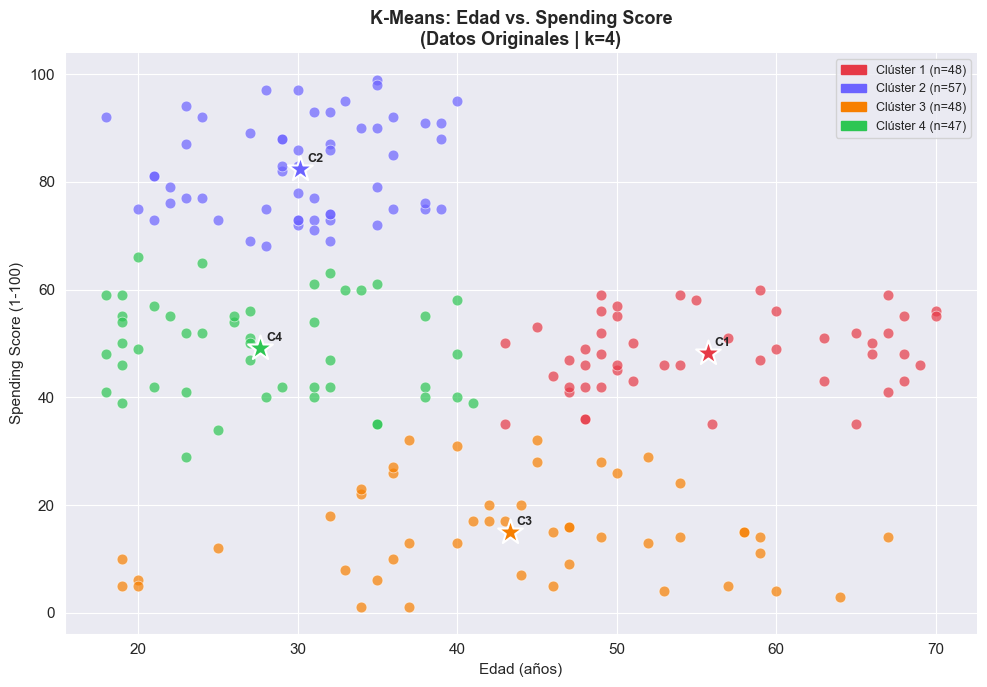

```
📋 Reporte del Modelo — K-Means: Edad vs. Spending Score (Datos Originales):
   • n_clusters  : 4
   • Inercia     : 28165.58
   • Iteraciones : 8
   • Silhouette  : 0.4997
   • init        : k-means++ | n_init: 10 | max_iter: 300 | random_state: 42
   • Distribución de clústeres:
     - Clúster 1: 48 clientes (24.0%)
     - Clúster 2: 57 clientes (28.5%)
     - Clúster 3: 48 clientes (24.0%)
     - Clúster 4: 47 clientes (23.5%)
```

```python
# ---- 14.3 Modelo 3: Age + Spending Score (Original) ----
print("="*60)
print("MODELO 3: Age + Spending Score — Datos Originales")
print("="*60)
km3, labels3 = entrenar_y_visualizar(
    X2, k=k2_orig,
    xlabel='Edad (años)', ylabel='Spending Score (1-100)',
    titulo='K-Means: Edad vs. Spending Score',
    datos_tipo='Datos Originales'
)
```

```
============================================================
MODELO 4: Age + Spending Score — Datos Normalizados
============================================================
```

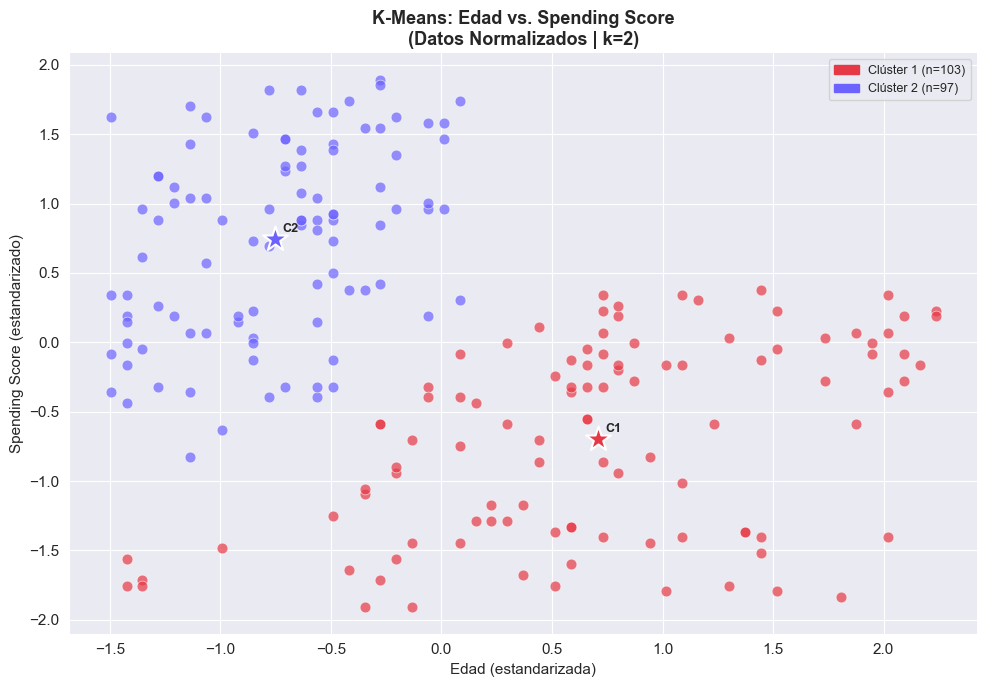

```
📋 Reporte del Modelo — K-Means: Edad vs. Spending Score (Datos Normalizados):
   • n_clusters  : 2
   • Inercia     : 189.39
   • Iteraciones : 2
   • Silhouette  : 0.4721
   • init        : k-means++ | n_init: 10 | max_iter: 300 | random_state: 42
   • Distribución de clústeres:
     - Clúster 1: 103 clientes (51.5%)
     - Clúster 2: 97 clientes (48.5%)
```

```python
# ---- 14.4 Modelo 4: Age + Spending Score (Normalizado) ----
print("="*60)
print("MODELO 4: Age + Spending Score — Datos Normalizados")
print("="*60)
km4, labels4 = entrenar_y_visualizar(
    X2_scaled, k=k2_norm,
    xlabel='Edad (estandarizada)', ylabel='Spending Score (estandarizado)',
    titulo='K-Means: Edad vs. Spending Score',
    datos_tipo='Datos Normalizados'
)
```

```
============================================================
MODELO 5: Annual Income + Spending Score — Datos Originales
============================================================
```

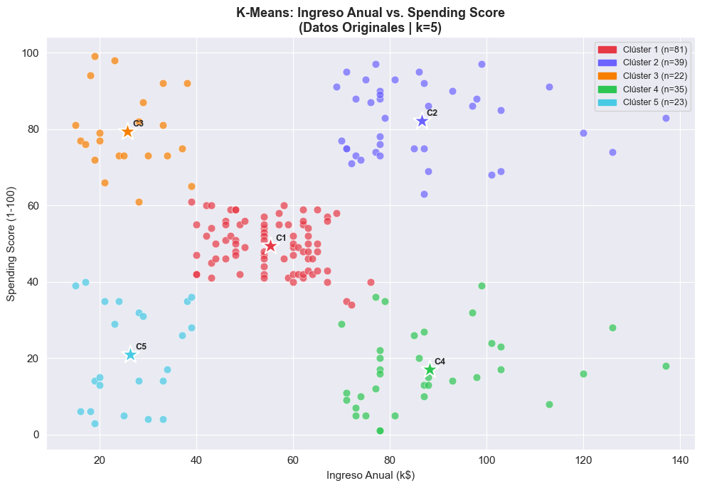

```
📋 Reporte del Modelo — K-Means: Ingreso Anual vs. Spending Score (Datos Originales):
   • n_clusters  : 5
   • Inercia     : 44448.46
   • Iteraciones : 4
   • Silhouette  : 0.5539
   • init        : k-means++ | n_init: 10 | max_iter: 300 | random_state: 42
   • Distribución de clústeres:
     - Clúster 1: 81 clientes (40.5%)
     - Clúster 2: 39 clientes (19.5%)
     - Clúster 3: 22 clientes (11.0%)
     - Clúster 4: 35 clientes (17.5%)
     - Clúster 5: 23 clientes (11.5%)
```

```python
# ---- 14.5 Modelo 5: Annual Income + Spending Score (Original) ----
print("="*60)
print("MODELO 5: Annual Income + Spending Score — Datos Originales")
print("="*60)
km5, labels5 = entrenar_y_visualizar(
    X3, k=k3_orig,
    xlabel='Ingreso Anual (k$)', ylabel='Spending Score (1-100)',
    titulo='K-Means: Ingreso Anual vs. Spending Score',
    datos_tipo='Datos Originales'
)
```

```
============================================================
MODELO 6: Annual Income + Spending Score — Datos Normalizados
============================================================
```

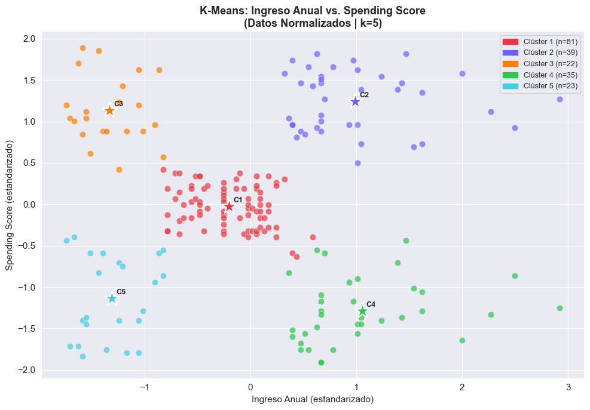

```
📋 Reporte del Modelo — K-Means: Ingreso Anual vs. Spending Score (Datos Normalizados):
   • n_clusters  : 5
   • Inercia     : 65.57
   • Iteraciones : 4
   • Silhouette  : 0.5547
   • init        : k-means++ | n_init: 10 | max_iter: 300 | random_state: 42
   • Distribución de clústeres:
     - Clúster 1: 81 clientes (40.5%)
     - Clúster 2: 39 clientes (19.5%)
     - Clúster 3: 22 clientes (11.0%)
     - Clúster 4: 35 clientes (17.5%)
     - Clúster 5: 23 clientes (11.5%)
```

```python
# ---- 14.6 Modelo 6: Annual Income + Spending Score (Normalizado) ----
print("="*60)
print("MODELO 6: Annual Income + Spending Score — Datos Normalizados")
print("="*60)
km6, labels6 = entrenar_y_visualizar(
    X3_scaled, k=k3_norm,
    xlabel='Ingreso Anual (estandarizado)', ylabel='Spending Score (estandarizado)',
    titulo='K-Means: Ingreso Anual vs. Spending Score',
    datos_tipo='Datos Normalizados'
)
```

```
============================================================
COMPARACIÓN: k=3, 4, 5, 6 — Ingreso vs. Spending Score
============================================================
```

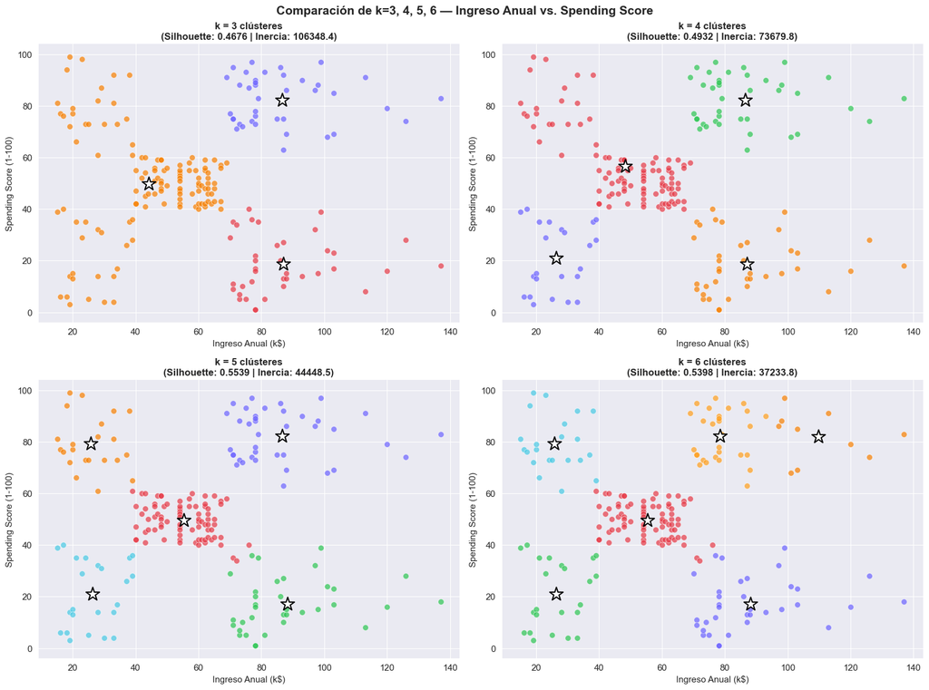

```
📌 Con k=3 los grupos son muy generales.
   Con k=5 se logra la mejor separación y la mayor interpretabilidad comercial.
   Con k=6 se fragmentan innecesariamente clústeres naturales.
```

```python
# ---- 14.7 Comparación: k=3, 4, 5, 6 en Annual Income + Spending Score ----
print("="*60)
print("COMPARACIÓN: k=3, 4, 5, 6 — Ingreso vs. Spending Score")
print("="*60)

fig, axes = plt.subplots(2, 2, figsize=(16, 12))
fig.suptitle('Comparación de k=3, 4, 5, 6 — Ingreso Anual vs. Spending Score',
             fontsize=15, fontweight='bold')
axes = axes.flatten()

for idx, k in enumerate([3, 4, 5, 6]):
    km_tmp = KMeans(n_clusters=k, init='k-means++', n_init=10, random_state=42)
    lbs_tmp = km_tmp.fit_predict(X3)
    cen_tmp = km_tmp.cluster_centers_
    sil_tmp = silhouette_score(X3, lbs_tmp)

    for cid in range(k):
        mask = lbs_tmp == cid
        axes[idx].scatter(X3[mask, 0], X3[mask, 1],
                         c=COLORS_CLUSTERS[cid], alpha=0.7, s=50,
                         edgecolors='white', linewidth=0.5)
    axes[idx].scatter(cen_tmp[:, 0], cen_tmp[:, 1], c='white', marker='*',
                     s=300, edgecolors='black', linewidth=1.5, zorder=5)
    axes[idx].set_title(f'k = {k} clústeres\n(Silhouette: {sil_tmp:.4f} | Inercia: {km_tmp.inertia_:.1f})',
                       fontweight='bold', fontsize=12)
    axes[idx].set_xlabel('Ingreso Anual (k$)')
    axes[idx].set_ylabel('Spending Score (1-100)')
    axes[idx].spines[['top','right']].set_visible(False)

plt.tight_layout()
plt.show()

print("\n📌 Con k=3 los grupos son muy generales.")
print("   Con k=5 se logra la mejor separación y la mayor interpretabilidad comercial.")
print("   Con k=6 se fragmentan innecesariamente clústeres naturales.")
```

```python
# ---- 14.8 Perfil de Clústeres del Modelo Principal (k=5, Income + Score) ----
print("="*60)
print("PERFIL DE CLÚSTERES — Annual Income + Spending Score (k=5)")
print("="*60)

df_perfil = df.copy()
df_perfil['Cluster'] = labels5

perfil = df_perfil.groupby('Cluster').agg(
    n_clientes=('CustomerID', 'count'),
    edad_media=('Age', 'mean'),
    ingreso_medio=('Annual Income (k$)', 'mean'),
    score_medio=('Spending Score (1-100)', 'mean'),
    pct_mujeres=('Gender', lambda x: (x == 'Female').mean() * 100)
).round(2)

perfil.index = [f'Clúster {i+1}' for i in perfil.index]
display(perfil)
print()

print("📌 Interpretación de perfiles:")
# Ordenamos por ingreso y score para determinar el tipo
for idx in range(df_perfil['Cluster'].nunique()):
    n = (labels5 == idx).sum()
    inc = df_perfil[df_perfil['Cluster'] == idx]['Annual Income (k$)'].mean()
    sc = df_perfil[df_perfil['Cluster'] == idx]['Spending Score (1-100)'].mean()
    tipo = ""
    if inc > 70 and sc > 60:
        tipo = "⭐ Alto Ingreso / Alto Gasto — Clientes PREMIUM"
    elif inc > 70 and sc < 45:
        tipo = "💼 Alto Ingreso / Bajo Gasto — Clientes CONSERVADORES"
    elif inc < 45 and sc > 60:
        tipo = "🛍️  Bajo Ingreso / Alto Gasto — Compradores IMPULSIVOS"
    elif inc < 45 and sc < 45:
        tipo = "😴 Bajo Ingreso / Bajo Gasto — Baja prioridad comercial"
    else:
        tipo = "📊 Ingreso Medio / Gasto Medio — CLIENTES PROMEDIO"
    print(f"   Clúster {idx+1}: {tipo}")
    print(f"            → Ingreso promedio: ${inc:.1f}k | Score promedio: {sc:.1f} | n={n}")
    print()
```

```
============================================================
PERFIL DE CLÚSTERES — Annual Income + Spending Score (k=5)
============================================================
```

|  | n_clientes | edad_media | ingreso_medio | score_medio | pct_mujeres |
| --- | --- | --- | --- | --- | --- |
| Clúster 1 | 81 | 42.72 | 55.30 | 49.52 | 59.26 |
| Clúster 2 | 39 | 32.69 | 86.54 | 82.13 | 53.85 |
| Clúster 3 | 22 | 25.27 | 25.73 | 79.36 | 59.09 |
| Clúster 4 | 35 | 41.11 | 88.20 | 17.11 | 45.71 |
| Clúster 5 | 23 | 45.22 | 26.30 | 20.91 | 60.87 |

```
📌 Interpretación de perfiles:
   Clúster 1: 📊 Ingreso Medio / Gasto Medio — CLIENTES PROMEDIO
            → Ingreso promedio: $55.3k | Score promedio: 49.5 | n=81

   Clúster 2: ⭐ Alto Ingreso / Alto Gasto — Clientes PREMIUM
            → Ingreso promedio: $86.5k | Score promedio: 82.1 | n=39

   Clúster 3: 🛍️  Bajo Ingreso / Alto Gasto — Compradores IMPULSIVOS
            → Ingreso promedio: $25.7k | Score promedio: 79.4 | n=22

   Clúster 4: 💼 Alto Ingreso / Bajo Gasto — Clientes CONSERVADORES
            → Ingreso promedio: $88.2k | Score promedio: 17.1 | n=35

   Clúster 5: 😴 Bajo Ingreso / Bajo Gasto — Baja prioridad comercial
            → Ingreso promedio: $26.3k | Score promedio: 20.9 | n=23
```

## 🏁 15. Conclusiones Finales

### 15.1 Perfiles de Clientes Identificados

A partir del modelo K-Means con 5 clústeres aplicado sobre **Ingreso Anual** y **Spending Score**, se identificaron cinco segmentos con características bien diferenciadas:

| Clúster | Perfil | Estrategia Recomendada |
| --- | --- | --- |
| ⭐ Alto Ingreso / Alto Gasto | Clientes premium, alta lealtad | Programas VIP, productos exclusivos |
| 💼 Alto Ingreso / Bajo Gasto | Clientes cautivos con potencial | Campañas de retención y descuentos |
| 🛍️ Bajo Ingreso / Alto Gasto | Compradores impulsivos jóvenes | Planes de pago, promociones |
| 😴 Bajo Ingreso / Bajo Gasto | Baja prioridad comercial | Comunicación mínima |
| 📊 Ingreso Medio / Gasto Medio | Clientes promedio | Marketing general y fidelización |

### 15.2 Comparación: Datos Originales vs. Normalizados

- En la combinación **Ingreso + Spending Score**, los resultados con datos originales y normalizados son casi idénticos porque ambas variables ya tienen escalas comparables.
- En la combinación **Age + Annual Income**, la normalización sí produce diferencias notables, ya que la edad (18-70) tiene una escala muy diferente al ingreso (15-137).
- En general, normalizar es siempre recomendable para K-Means.

### 15.3 Efecto de Distintas Cantidades de Clústeres

- **k=3**: Los grupos son demasiado generales. Se pierde diferenciación importante.
- **k=4**: Mejora la separación, pero aún mezcla algunos perfiles.
- **k=5**: Captura la estructura natural más importante. Máximo Silhouette Score.
- **k=6+**: Empieza a fragmentar clústeres naturales, creando grupos sin interpretación clara.

### 15.4 Limitaciones de K-Means y del Dataset

**Limitaciones de K-Means:**

- Requiere especificar `k` de antemano, lo cual no siempre es obvio
- Asume clústeres de forma esférica y tamaño similar
- Sensible a outliers: un dato extremo puede sesgar un centroide
- Los resultados pueden variar sin `random_state` fijo

**Limitaciones del Dataset:**

- Solo 200 registros: poco para conclusiones estadísticamente robustas
- El Spending Score es subjetivo (asignado por el mall)
- No hay información temporal (no sabemos si los hábitos cambian)
- Solo 5 variables: más atributos enriquecerían el análisis

```python
# ============================================================
# SECCIÓN 15: Resumen Final de Todos los Modelos
# ============================================================

print("="*65)
print("📊 RESUMEN FINAL DE TODOS LOS MODELOS K-MEANS ENTRENADOS")
print("="*65)

modelos_resumen = [
    ("Age + Annual Income",       "Original",    km1, X1,        labels1),
    ("Age + Annual Income",       "Normalizado", km2, X1_scaled, labels2),
    ("Age + Spending Score",      "Original",    km3, X2,        labels3),
    ("Age + Spending Score",      "Normalizado", km4, X2_scaled, labels4),
    ("Income + Spending Score",   "Original",    km5, X3,        labels5),
    ("Income + Spending Score",   "Normalizado", km6, X3_scaled, labels6),
]

filas = []
for comb, tipo, km_m, Xm, lbs in modelos_resumen:
    filas.append({
        'Combinación': comb,
        'Datos': tipo,
        'k': km_m.n_clusters,
        'Inercia': round(km_m.inertia_, 2),
        'Iteraciones': km_m.n_iter_,
        'Silhouette': round(silhouette_score(Xm, lbs), 4)
    })

resumen_df = pd.DataFrame(filas)
display(resumen_df)

print()
mejor = resumen_df.loc[resumen_df['Silhouette'].idxmax()]
print(f"🏆 Mejor modelo: {mejor['Combinación']} ({mejor['Datos']}) con k={mejor['k']}")
print(f"   Silhouette Score: {mejor['Silhouette']}")
```

```
=================================================================
📊 RESUMEN FINAL DE TODOS LOS MODELOS K-MEANS ENTRENADOS
=================================================================
```

|  | Combinación | Datos | k | Inercia | Iteraciones | Silhouette |
| --- | --- | --- | --- | --- | --- | --- |
| 0 | Age + Annual Income | Original | 4 | 39502.78 | 6 | 0.4337 |
| 1 | Age + Annual Income | Normalizado | 3 | 132.86 | 5 | 0.4431 |
| 2 | Age + Spending Score | Original | 4 | 28165.58 | 8 | 0.4997 |
| 3 | Age + Spending Score | Normalizado | 2 | 189.39 | 2 | 0.4721 |
| 4 | Income + Spending Score | Original | 5 | 44448.46 | 4 | 0.5539 |
| 5 | Income + Spending Score | Normalizado | 5 | 65.57 | 4 | 0.5547 |

```
🏆 Mejor modelo: Income + Spending Score (Normalizado) con k=5
   Silhouette Score: 0.5547
```

### 💬 Conclusiones Personales — Conclusiones Finales

Esta práctica me dejó una comprensión mucho más real de lo que significa aprender sin etiquetas. El clustering no es solo dividir datos en grupos, es encontrar estructura donde aparentemente hay solo puntos dispersos. Lo que más me quedó claro es que la selección de qué variables usar es tan importante como el algoritmo mismo: con Age + Annual Income los grupos no son tan claros como con Income + Spending Score, y eso es porque estas dos últimas variables tienen una relación más directa con el comportamiento de compra. También me parece valioso haber aplicado el mismo proceso con datos originales y normalizados, porque no siempre la normalización cambia mucho, pero cuando las escalas son muy diferentes sí hace una diferencia real. Al final, K-Means es una herramienta poderosa pero con limitaciones claras: si los datos no tienen grupos naturales bien formados, el algoritmo igual te dará grupos aunque no existan de verdad.